# Table of Contents (Jupyter)

### language and domain

```
Contingency Table:
domain    mediawiki.org  wikimedia.org  wikipedia.org
language
commons               0          10477              0
de                    0              0          18438
en                    0              0          24010
es                    0              0          14041
fr                    0              0          17761
ja                    0              0          20340
ru                    0              0          14990
www                7251              0              0
zh                    0              0          17103


Chi-square Test Results:
Chi-square statistic: 288822.0000
p-value: 0.0000
Degrees of freedom: 16
Significant at α=0.05: Yes
Reject Null Hypothesis. Alternate Hypothesis '<li>language and domain are DEPENDENT' is True, p-value:0.0. And, association is Strong(CramersV=1.00)
```

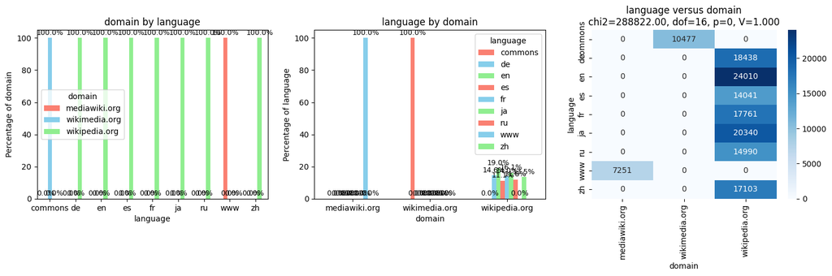

```python
perform_chi_square_test(df, "language", "domain",figsize=(15, 5))
```

language and domain are DEPENDENT, p-value:0.0. And, association is Strong(CramersV=1.00)

All www marked pages belong to mediawiki.org

All commons marked pages belong to wikimedia.org

All language marked pages belong to wikipedia.org

This corroborates our understanding - wikipedia.org has the text content, so it has language-based pages, while wikimedia has audio, video and images, which are (supposedly) language agnostic (which may not be technically correct,but the case study has this assumption, there is no marker on the media files what language they are in.)

```
Contingency Table:
domain         mediawiki.org  wikimedia.org  wikipedia.org
access_origin
all-agents              5516           7947          96167
spider                  1735           2530          30516


Chi-square Test Results:
Chi-square statistic: 0.1218
p-value: 0.9409
Degrees of freedom: 2
Significant at α=0.05: No
Fail to Reject Null Hypothesis. Null Hypothesis '<li>access_origin and domain are independent.' is True, p-value:0.9409393320466397
```

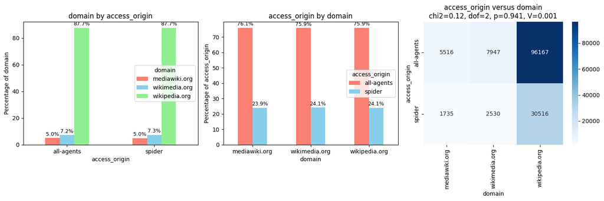

```python
perform_chi_square_test(df, "access_origin", "domain",figsize=(15, 5))
```

access_origin and domain are independent

### access_type and domain

```
Contingency Table:
domain       mediawiki.org  wikimedia.org  wikipedia.org
access_type
all-access            3473           5061          65468
desktop               1681           2526          30389
mobile-web            2097           2890          30826


Chi-square Test Results:
Chi-square statistic: 133.6559
p-value: 0.0000
Degrees of freedom: 4
Significant at α=0.05: Yes
Reject Null Hypothesis. Alternate Hypothesis '<li>access_type and domain are DEPENDENT' is True, p-value:6.432905337976179e-28. However, association is Negligible(CramersV=0.02)
```

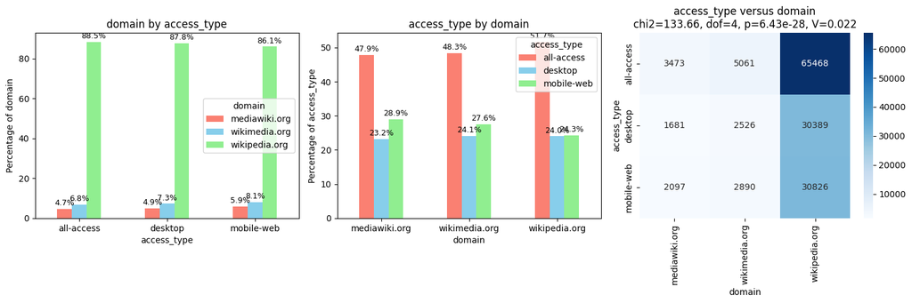

```python
# _ = chi2_categorical_pair(df, "access_type", "domain", plot=True, annot=True)
perform_chi_square_test(df, "access_type", "domain",figsize=(15, 5))
```

access_type and domain are DEPENDENT' is True, p-value:6.432905337976179e-28. However, association is Negligible(CramersV=0.02)

## Multivariate Analysis

### Language, access_origin, access_type and clickCount

We want to see if access_origin is non spider, then for various languages, does clickCount change based on access_type

We first check for language=www and access_type=desktop

```
search_data():Searched random 10 rows where access_origin == all-agents and language == www and access_type == desktop
extractRowTransposeColumn():Transposing ALL rows from given dataframe that has 10 rows
```

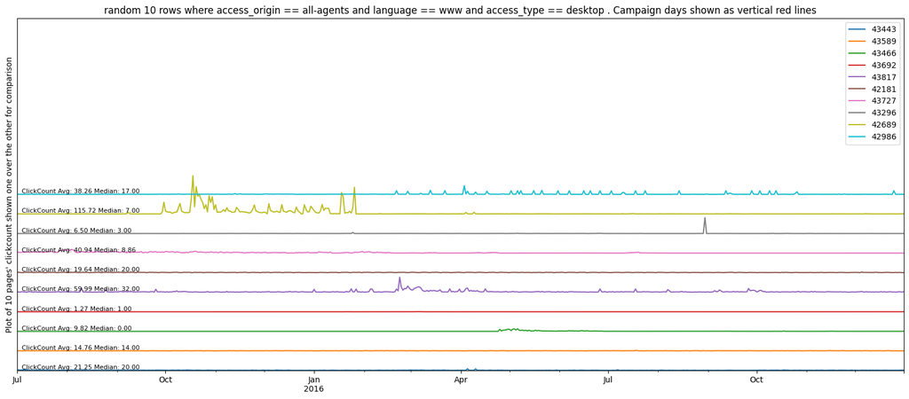

```python
rows,title=search_data(10,
                       colName1='access_origin',val1='all-agents',
                       colName2='language',val2='www',
                       colName3='access_type',val3='desktop')
plot_data_staggered(rows, title, campaign=True)
```

```
search_data():Searched random 10 rows where access_origin == all-agents and language == www and access_type == mobile-web
extractRowTransposeColumn():Transposing ALL rows from given dataframe that has 10 rows
```

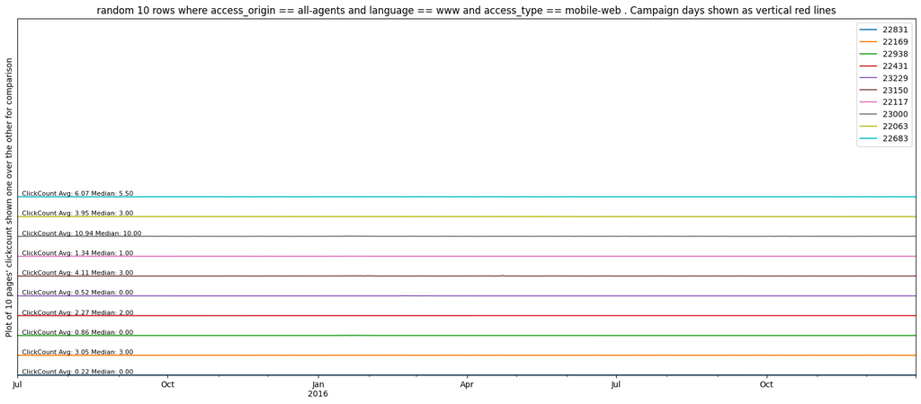

```python
rows,title=search_data(10,
                       colName1='access_origin',val1='all-agents',
                       colName2='language',val2='www',
                       colName3='access_type',val3='mobile-web')
plot_data_staggered(rows, title, campaign=True)
```

```
search_data():Searched random 10 rows where access_origin == all-agents and language == www and access_type == all-access
extractRowTransposeColumn():Transposing ALL rows from given dataframe that has 10 rows
```

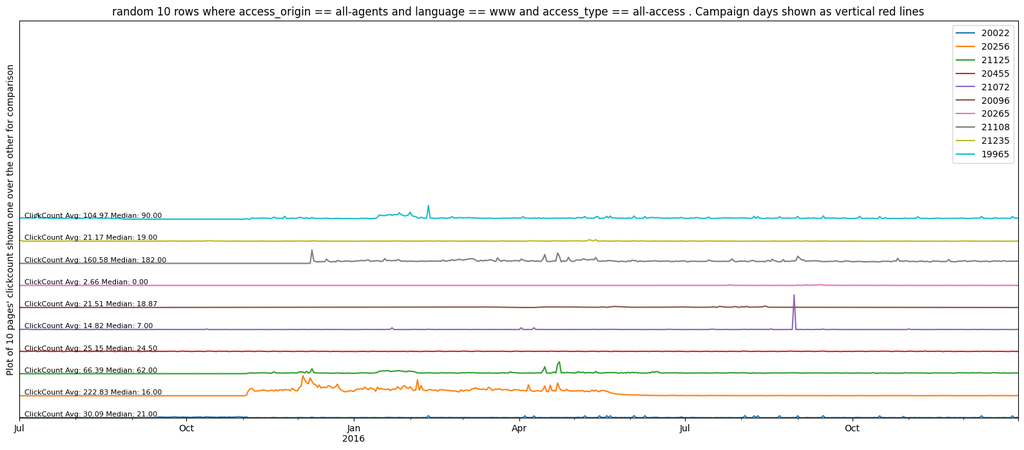

```python
rows,title=search_data(10,
                       colName1='access_origin',val1='all-agents',
                       colName2='language',val2='www',
                       colName3='access_type',val3='all-access')
plot_data_staggered(rows, title, campaign=True)
```

Lets now check for a real language, say english

```
search_data():Searched random 10 rows where access_origin == all-agents and language == en and access_type == desktop
extractRowTransposeColumn():Transposing ALL rows from given dataframe that has 10 rows
```

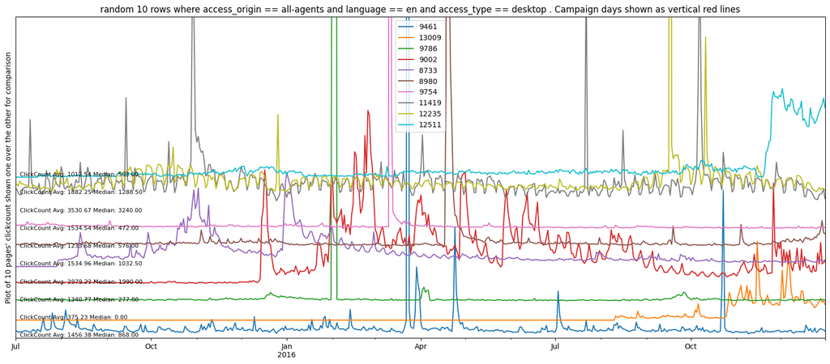

```
search_data():Searched random 10 rows where access_origin == all-agents and language == en and access_type == mobile-web
extractRowTransposeColumn():Transposing ALL rows from given dataframe that has 10 rows
```

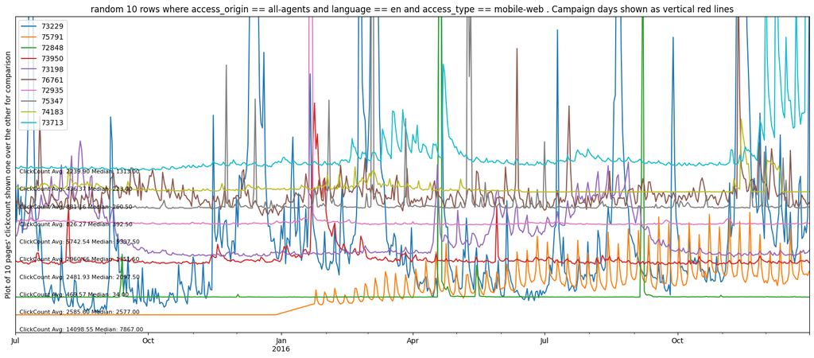

```
search_data():Searched random 10 rows where access_origin == all-agents and language == en and access_type == all-access
extractRowTransposeColumn():Transposing ALL rows from given dataframe that has 10 rows
```

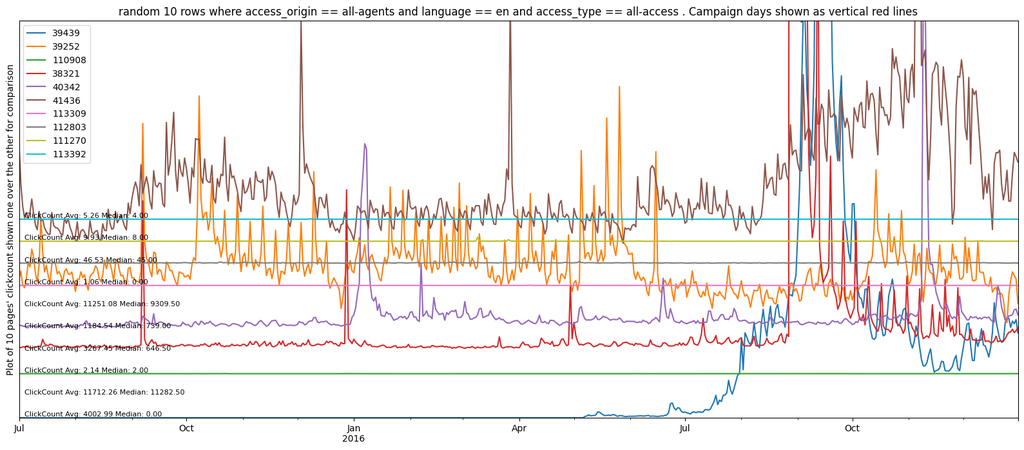

```python
lang='en'
rows,title=search_data(10,
                       colName1='access_origin',val1='all-agents',
                       colName2='language',val2=lang,
                       colName3='access_type',val3='desktop')
plot_data_staggered(rows, title, campaign=True)


rows,title=search_data(10,
                       colName1='access_origin',val1='all-agents',
                       colName2='language',val2=lang,
                       colName3='access_type',val3='mobile-web')
plot_data_staggered(rows, title, campaign=True)


rows,title=search_data(10,
                       colName1='access_origin',val1='all-agents',
                       colName2='language',val2=lang,
                       colName3='access_type',val3='all-access')
plot_data_staggered(rows, title, campaign=True)
```

Results are similar for en too across different access_types, so **access type cannot be used for data segmentation** even for non spider pages

## Segmentation logic

- We have figured out from all the EDA analysis that `access_origin` and `language`s are two good criteria for segmenting the data.
- We will create a separate model for each segment so that hopefully the model can predict better compared to if a single model is used across all data.
- The CARD SHAPE in the diagram show the MODEL NAMES

```
flowchart TD
    A["Full Data"] --> B["Criteria = Access Origin"]
    B -->|"All Spider Rows"| C@{ shape: notch-rect, label: "ModelSpider" }
    B -->|"All Non-Spider Rows"| E{"Criteria = Languages"}

    E -->|"Non Spider Common Rows"| F@{ shape: notch-rect, label: "ModelNonSpiderLangCommons" }
    E -->|"Non Spider de Rows"| G@{ shape: notch-rect, label: "ModelNonSpiderLangDe" }
    E -->|"Non Spider en Rows"| H@{ shape: notch-rect, label: "ModelNonSpiderLangEn" }
    E -->|"Non Spider es Rows"| I@{ shape: notch-rect, label: "ModelNonSpiderLangEs" }
    E -->|"Non Spider fr Rows"| J@{ shape: notch-rect, label: "ModelNonSpiderLangFr" }
    E -->|"Non Spider ja Rows"| K@{ shape: notch-rect, label: "ModelNonSpiderLangJa" }
    E -->|"Non Spider ru Rows"| L@{ shape: notch-rect, label: "ModelNonSpiderLangRu" }
    E -->|"Non Spider www Rows"| M@{ shape: notch-rect, label: "ModelNonSpiderLangWww" }
    E -->|"Non Spider zh Rows"| N@{ shape: notch-rect, label: "ModelNonSpiderLangZh" }

    style C fill:#DEB887,stroke:#333,stroke-width:2px,color:#222
    style F fill:#DEB887,stroke:#333,stroke-width:2px,color:#222
    style G fill:#DEB887,stroke:#333,stroke-width:2px,color:#222
    style H fill:#DEB887,stroke:#333,stroke-width:2px,color:#222
    style I fill:#DEB887,stroke:#333,stroke-width:2px,color:#222
    style J fill:#DEB887,stroke:#333,stroke-width:2px,color:#222
    style K fill:#DEB887,stroke:#333,stroke-width:2px,color:#222
    style L fill:#DEB887,stroke:#333,stroke-width:2px,color:#222
    style M fill:#DEB887,stroke:#333,stroke-width:2px,color:#222
    style N fill:#DEB887,stroke:#333,stroke-width:2px,color:#222
```

**Aggregated Modeling Strategy:**

- Rather than building separate models for each of the ~145,000 Wikipedia pages, we will aggregate pageviews at the segment level (e.g., all Spider traffic, all English non-Spider traffic).
- This approach offers three advantages:
  - (1) computational efficiency—training 10 models instead of 145,000;
  - (2) statistical robustness—aggregation smooths outliers and sparse pages with near-zero traffic;
  - (3) alignment with business objectives—segment-level forecasts support capacity planning and resource allocation decisions. Model parameters shall be validated on multiple sampled pages before applying to the full aggregated series.

### **Brief Summary of Multi-Series Forecasting Options**

> **Alternative Approaches Considered:**
> - **Aggregated Model:** Sum all pages into one series per segment—simple, efficient, ideal for segment-level forecasts (chosen approach)
> - **Multi-Sample Parameter Tuning:** Test parameters on 50-100 random pages to find robust settings that generalize across pages
> - **Global ML Model:** Train one machine learning model (e.g., LightGBM) that learns patterns from all series simultaneously for page-level predictions
> - **Cluster-then-Forecast:** Group similar pages using clustering, then train separate models per cluster
> - **Deep Learning:** Use neural architectures (DeepAR, N-BEATS, Temporal Fusion Transformer) designed for large-scale multi-series forecasting

| Approach | Description | Best For |
| --- | --- | --- |
| **Aggregated (Chosen)** | Sum all pages → one model per segment | Segment-level forecasts |
| **Multi-Sample Tuning** | Validate params on 50-100 pages | Robust parameter selection |
| **Global ML Model** | One model learns from all series | Scalable page-level forecasts |
| **Cluster + Forecast** | Group similar pages, model per cluster | Heterogeneous page patterns |
| **Deep Learning** | Neural nets (DeepAR, N-BEATS) | Large-scale, complex patterns |

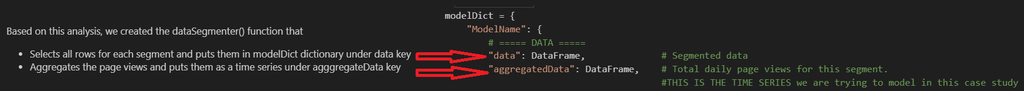

```python
#Need to fix this.
# plot_transposed_data_staggered(timeSeriesFull_df[[modelNames[3]]], title="All segments", staggerByY=100, campaign=False)
```

# 4.0 Modeling

## 4.1 Pipeline Flow Design

```
flowchart TB
    %% Input Stage
    subgraph Input["📥 Data Input"]
        A["Raw Data"] -->|fn:ingesterCleanerImputerEngineer| B["df_with_extra_columns"]
    end

    %% Segmentation Stage -- now vertical!
    subgraph Segmentation["🔀 Segment Logic (fn:dataSegmenter)"]
        B -->B1["Manually for each segment"]
        B1 -->|fn:search_data|C["Data Split by access_origin & language"]
        C-->|fn:prepare_time_series| D["Data Aggregated as time series for each segment"]
        D-->|
          ModelSpider
          ModelNonSpiderLangCommons
          ModelNonSpiderLangDe
          ModelNonSpiderLangEn
          ModelNonSpiderLangEs
          ModelNonSpiderLangFr
          ModelNonSpiderLangJa
          ModelNonSpiderLangRu
          ModelNonSpiderLangWww
          ModelNonSpiderLangZh
        | X["For each segment"]
    end

    %% Pipeline, only once, with "per segment" label
    subgraph Pipeline["⚙️ Model Pipeline (per segment)"]
        direction TB
        E2["2️⃣ Train/Test Split"] --> E3["3️⃣ Hyperparameter Tuning (GridSearchCV)"]
        E3 --> E4["4️⃣ Train Selected Model"]
        E4 --> E5["5️⃣ Calculate MAPE"]
        E5 --> E6["6️⃣ Store in modelDict (per segment)"]
    end

    X --> Pipeline

    %% Outputs grouped in one block
    subgraph Output["📊 Output (modelDict, all segments)"]
      F["All Segments:
      - ModelSpider ✓ model ✓ MAPE
      - ModelNonSpiderLangCommons ✓ model ✓ MAPE
      - ModelNonSpiderLangDe ✓ model ✓ MAPE
      - ModelNonSpiderLangEn ✓ model ✓ MAPE
      - ModelNonSpiderLangEs ✓ model ✓ MAPE
      - ModelNonSpiderLangFr ✓ model ✓ MAPE
      - ModelNonSpiderLangJa ✓ model ✓ MAPE
      - ModelNonSpiderLangRu ✓ model ✓ MAPE
      - ModelNonSpiderLangWww ✓ model ✓ MAPE
      - ModelNonSpiderLangZh ✓ model ✓ MAPE"]
    end

    E6 --> F

    %% Summary (single output target)
    subgraph Summary["📋 Summary (printModelDictSummary)"]
        F --> G["Summary Table + Model Pickle Files"]
    end
```

## Take a sample data and analyse

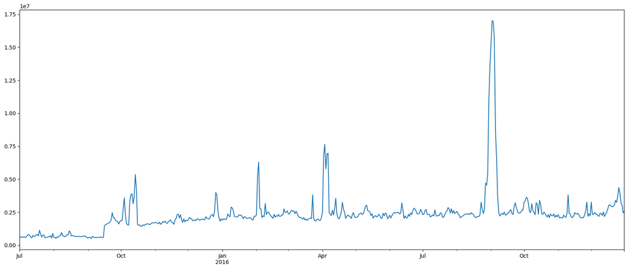

```python
timeSeriesFull_df.iloc[:,0].plot()
```

### Stationarity check (ADF test)

```python
from statsmodels.tsa.stattools import adfuller

print("Testing for ALL segments")

def performADFTestForAllSegments(full_df):
    results = []

    for i in range(len(full_df.columns)):
        adf_result = adfuller(full_df.iloc[:,i].dropna())
        status = "Stationary" if adf_result[1] < 0.05 else "Non-Stationary"
        results.append([modelNames[i], f'{adf_result[1]:.4e}', status])

    print(tabulate(results, headers=['Model', 'P-Value', 'Status'], tablefmt='simple'))

performADFTestForAllSegments(timeSeriesFull_df)
```

```
Testing for ALL segments
Model                         P-Value  Status
-------------------------  ----------  --------------
ModelSpider                1.2515e-05  Stationary
ModelNonSpiderLangCommons  0.059171    Non-Stationary
ModelNonSpiderLangDe       0.15129     Non-Stationary
ModelNonSpiderLangEn       0.18904     Non-Stationary
ModelNonSpiderLangEs       0.037999    Stationary
ModelNonSpiderLangFr       0.045776    Stationary
ModelNonSpiderLangJa       0.088203    Non-Stationary
ModelNonSpiderLangRu       0.0019096   Stationary
ModelNonSpiderLangWww      1.4259e-08  Stationary
ModelNonSpiderLangZh       0.43604     Non-Stationary
```

**Interpreting the ADF test results**

The **Augmented Dickey–Fuller (ADF) test** checks for a unit root:

- **Null hypothesis (H₀):** series is **non‑stationary**
- **Alternative (H₁):** series is **stationary**
- Typically, **p-value < 0.05 ⇒ reject H₀ ⇒ stationary**

[output not shown]

Key observations

**What this means for modeling**

**✅ For stationary segments** We can directly use:

- **ARMA**
- **ARIMA with d=0**
- **VAR (if multivariate)**

Examples:

- Spider
- ES, FR, RU, WWW

**❌ For non‑stationary segments** We should transform the data before modeling:

**Common fixes**

1. **First differencing**

```
y_diff = y.diff().dropna()
```

Then rerun ADF.

2. **Seasonal differencing** (very likely for click data)

```
y_seasonal_diff = y.diff(7)   # daily data
y.diff(30)                    # monthly seasonality
```

3. **Log + differencing**

```
y_log = np.log1p(y)
y_log_diff = y_log.diff().dropna()
```

✅ Wikipedia traffic almost always benefits from **log + seasonal differencing**.

### ACF PACF

ACF and PACF can reveal the underlying dependence structure in a time series—specifically how current values relate to past values at different lags.

**Model identification (AR / MA / ARIMA)**

- PACF helps identify the order of an AR(p) model (sharp cutoff after lag p).
- ACF helps identify the order of an MA(q) model (sharp cutoff after lag q).

**Detecting autocorrelation & seasonality**

- Significant spikes at regular intervals indicate seasonal patterns (e.g., lag 7 for weekly seasonality).
- Helps confirm whether the data is truly independent over time or not.
- Checking stationarity and model adequacy
- Slowly decaying ACF suggests non-stationarity (need differencing).

**ACF (Autocorrelation Function)**

- Correlation between **Yₜ** and **Yₜ₋ₖ**
- Used mainly to identify q in **MA (q)**

**PACF (Partial Autocorrelation Function)**

- Direct correlation between **Yₜ** and **Yₜ₋ₖ**, removing intermediate effects
- Used mainly to identify p in **AR (p)**

```python
from statsmodels.graphics.tsaplots import plot_acf, plot_pacf

def plotACFForAllSegments(full_df):
    for i in range(len(full_df.columns)):
            plot_acf(full_df.iloc[:,i].dropna(), title=f'ACF for {modelNames[i]}')

print("Plotting for ALL segments")
plotACFForAllSegments(timeSeriesFull_df)
```

**How to Read the ACF Results Table**

The ACF (Autocorrelation Function) answers one core question:

> **How strongly is the series correlated with its own past values at different lags?**

[output not shown]

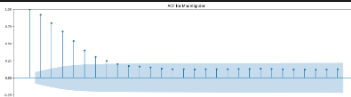

| **ModelSpider** | Very high | Smooth, monotonic decay | None | Moderate | ✅ Stationary | |

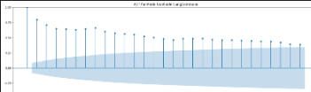

| **NonSpiderLangCommons** | Very high | Very slow decay | None | ❌ Non‑stationary | |

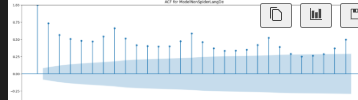

| **NonSpiderLangDe** | High | Slow decay | Present | Strong | ❌ Non‑stationary | |

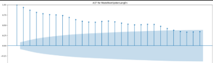

| **NonSpiderLangEn** | Very high | Extremely slow decay | Weak | ❌ Non‑stationary | |

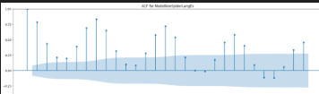

| **NonSpiderLangEs** | High | Non‑monotonic decay | Strong | Moderate | ✅ Stationary | |

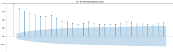

| **NonSpiderLangFr** | High | Gradual decay | Mild | Moderate | ✅ Stationary | |

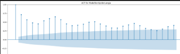

| **NonSpiderLangJa** | High | Slow decay | Moderate | Strong |❌ Non‑stationary | |

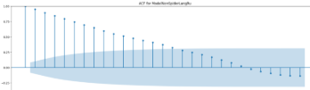

| **NonSpiderLangRu** | Very high | Smooth decay | None | Moderate | ✅ Stationary | |

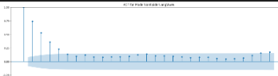

| **NonSpiderLangWww** | Moderate | Fast decay | None | Weak | ✅ Stationary | |

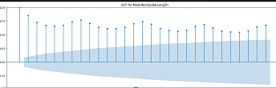

| **NonSpiderLangZh** | Very high | Very slow decay | Strong | ❌ Non‑stationary |

1. **Lag‑1 Autocorrelation**

**What it is** The autocorrelation at lag 1:

**Why it’s included**

- It measures **immediate temporal dependence**
- It is the **single most informative ACF value**
- High lag‑1 correlation implies strong inertia in the series

**Why it matters**

- Distinguishes:
  - noisy processes (low lag‑1)
  - persistent processes (high lag‑1)
- Helps compare segments **on the same scale**

📌 Example interpretation:

- Lag‑1 ≈ 0.9 → strong dependence
- Lag‑1 ≈ 0.3 → weak memory
2. **ACF Decay Behavior**

**What it describes ** The **shape of the ACF envelope** as lag increases:

- Fast decay
- Slow decay
- Monotonic vs irregular

**Why it’s included** The *rate* of decay contains information that **no single lag can capture**.

**Why it matters** Decay behavior tells us:

- Whether dependence is short‑range or long‑range
- Whether correlations die out quickly or persist

📌 Typical patterns:

- **Fast decay** → short memory
- **Slow decay** → long memory or structural dependence
3. **Oscillation / Cyclic Pattern**

**What it captures** Whether the ACF:

- Alternates signs
- Shows repeating peaks
- Exhibits wave‑like structure

**Why it’s included** Oscillations indicate **systematic structure in correlations**, not random noise.

⚠️ Important distinction:

- This **does NOT assert seasonality**
- It only states that correlations fluctuate in a patterned way

**Why it matters**

- Separates:
  - smooth AR‑like decay
  - cyclic dependence
- Signals that **dependence is not purely monotonic**
4. **High‑Lag Persistence**

**What it means** Whether autocorrelations:

- Remain statistically significant at large lags
- Or drop into the confidence band quickly

**Why it’s included** High‑lag behavior captures **global dependence**, not local structure.

**Why it matters**

- Long persistence suggests:
  - cumulative dependence
  - slow information decay
- Short persistence suggests:
  - rapid loss of memory

📌 This column helps distinguish:

- series that “remember far back”
- series dominated by recent history only

✅ This is directly observable from the ACF confidence bounds.

```python
# plot_pacf(ts);

def plotPACFForAllSegments(full_df):
    for i in range(len(full_df.columns)):
            plot_acf(full_df.iloc[:,i].dropna(), title=f'Partial Autocorrelation for {modelNames[i]}')

print("Plotting for ALL segments")
plotPACFForAllSegments(timeSeriesFull_df)
```

Plot

Segment

ADF Result

PACF Pattern (Key Lags)

Conclusion

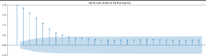

**ModelSpider**

Stationary

Strong AR‑type dependence

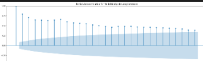

**NonSpiderLangCommons**

Non‑stationary

PACF dominated by non‑stationarity

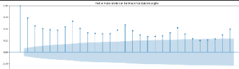

**NonSpiderLangDe**

Non‑stationary

Structure obscured by non‑stationarity

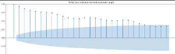

**NonSpiderLangEn**

Non‑stationary

PACF not interpretable pre‑differencing

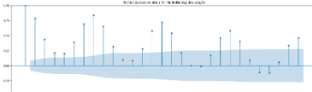

**NonSpiderLangEs**

Stationary

Finite AR structure plausible

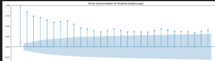

**NonSpiderLangFr**

Stationary

Weak to moderate AR dependence

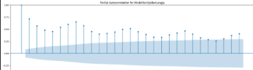

**NonSpiderLangJa**

Non‑stationary

Differencing required before interpretation

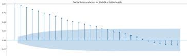

**NonSpiderLangRu**

Stationary

Clear AR‑type structure

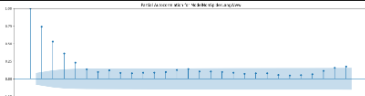

**NonSpiderLangWww**

Stationary

Short‑memory AR behavior

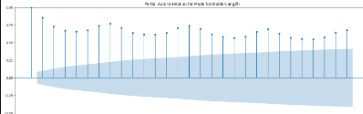

**NonSpiderLangZh**

Non‑stationary

PACF dominated by trend effects

Next we will:

- Recompute **PACF after differencing** (only for non‑stationary series)

Difference the identified columns

```python
timeSeriesFull_df
```

|  | ModelSpider | ModelNonSpiderLangCommons | ModelNonSpiderLangDe | ModelNonSpiderLangEn | ModelNonSpiderLangEs | ModelNonSpiderLangFr | ModelNonSpiderLangJa | ModelNonSpiderLangRu | ModelNonSpiderLangWww | ModelNonSpiderLangZh |
| --- | --- | --- | --- | --- | --- | --- | --- | --- | --- | --- |
| 2015-07-01 | 6.646480e+05 | 1.115089e+06 | 1.322512e+07 | 8.443447e+07 | 1.516379e+07 | 8.413729e+06 | 1.182696e+07 | 9.413485e+06 | 336127.000000 | 4.079057e+06 |
| 2015-07-02 | 6.197182e+05 | 1.134739e+06 | 1.304097e+07 | 8.418241e+07 | 1.449318e+07 | 8.479033e+06 | 1.359356e+07 | 9.586055e+06 | 365671.719048 | 4.101140e+06 |
| 2015-07-03 | 5.952534e+05 | 1.104986e+06 | 1.251964e+07 | 7.992619e+07 | 1.333192e+07 | 8.148049e+06 | 1.227274e+07 | 8.881341e+06 | 310775.711905 | 4.075526e+06 |
| 2015-07-04 | 6.140900e+05 | 9.228855e+05 | 1.147857e+07 | 8.321397e+07 | 1.252267e+07 | 8.710327e+06 | 1.541737e+07 | 8.342130e+06 | 285248.814610 | 4.108547e+06 |
| 2015-07-05 | 6.225934e+05 | 1.012272e+06 | 1.335621e+07 | 8.596247e+07 | 1.361801e+07 | 8.554636e+06 | 1.479098e+07 | 8.891764e+06 | 307448.917316 | 4.381881e+06 |
| ... | ... | ... | ... | ... | ... | ... | ... | ... | ... | ... |
| 2016-12-27 | 3.983575e+06 | 2.461968e+06 | 2.020611e+07 | 1.446777e+08 | 1.496376e+07 | 1.443103e+07 | 1.573815e+07 | 1.508121e+07 | 315218.002381 | 6.390221e+06 |
| 2016-12-28 | 3.200140e+06 | 2.757122e+06 | 1.922440e+07 | 1.405430e+08 | 1.548017e+07 | 1.360866e+07 | 1.577596e+07 | 1.404317e+07 | 729111.316667 | 6.416712e+06 |
| 2016-12-29 | 3.044633e+06 | 2.464330e+06 | 1.852005e+07 | 1.498275e+08 | 1.479296e+07 | 1.323288e+07 | 1.721980e+07 | 1.351904e+07 | 318100.616667 | 5.942536e+06 |
| 2016-12-30 | 2.447544e+06 | 2.664459e+06 | 1.767950e+07 | 1.247001e+08 | 1.141816e+07 | 1.228000e+07 | 1.890569e+07 | 1.208109e+07 | 418633.583333 | 6.018307e+06 |
| 2016-12-31 | 2.599010e+06 | 2.334855e+06 | 1.661956e+07 | 1.229791e+08 | 1.090994e+07 | 1.128594e+07 | 2.373262e+07 | 1.326381e+07 | 383315.000000 | 6.207837e+06 |

550 rows × 10 columns

```python
timeSeriesFull_differenced_df = timeSeriesFull_df.copy()

non_stationary_cols = [
    "ModelNonSpiderLangCommons",
    "ModelNonSpiderLangDe",
    "ModelNonSpiderLangEn",
    "ModelNonSpiderLangJa",
    "ModelNonSpiderLangZh"
]

periods=1
timeSeriesFull_differenced_df[non_stationary_cols] = timeSeriesFull_differenced_df[non_stationary_cols].diff(periods=periods)
timeSeriesFull_differenced_df = timeSeriesFull_differenced_df.dropna()
performADFTestForAllSegments(timeSeriesFull_differenced_df)
```

```
Model                         P-Value  Status
-------------------------  ----------  ----------
ModelSpider                1.2963e-05  Stationary
ModelNonSpiderLangCommons  5.635e-23   Stationary
ModelNonSpiderLangDe       1.8144e-10  Stationary
ModelNonSpiderLangEn       1.4166e-12  Stationary
ModelNonSpiderLangEs       0.036535    Stationary
ModelNonSpiderLangFr       0.039369    Stationary
ModelNonSpiderLangJa       7.7179e-20  Stationary
ModelNonSpiderLangRu       0.0019986   Stationary
ModelNonSpiderLangWww      1.4353e-08  Stationary
ModelNonSpiderLangZh       1.6898e-11  Stationary
```

So with period=1, we are able to make the non stationary series as stationary. Thus for these sereis, we will use d=1

Now that all series are stationary, lets plot ACF PACF again

**Rule (Box–Jenkins)** Both ACF and PACF used for identifying p and q must be computed on a stationary series.

```python
print("Plotting ACF for ALL segments")
plotACFForAllSegments(timeSeriesFull_differenced_df)

print("Plotting PACF for ALL segments")
plotPACFForAllSegments(timeSeriesFull_differenced_df)
```

**How ARIMA parameters can be decided based on ACF and PACF results**

Rule for **d**

- `d = 0` if original series is ADF‑stationary
- `d = 1` if original series is non‑stationary and  
  ✅ ADF on first‑differenced series is stationary (your confirmation)

✅ No series uses `d > 1`

**Gold‑standard Box–Jenkins rules**

| Pattern | ACF | PACF | Interpretation |
| --- | --- | --- | --- |
| **AR(p)** | Tails off | Cuts off at p | AR‑dominated |
| **MA(q)** | Cuts off at q | Tails off | MA‑dominated |
| **ARMA(p,q)** | Both tail off | Both tail off | Mixed |

**✅ Rule for p (from PACF)**

- Clear cutoff at lag k → p = k
- Strong lag‑1 only → p = 1
- No clear low‑lag cutoff → p = 0

**✅ Rule for `q`**

> **Choose `q` ONLY when the ACF shows a clear cutoff.**

If the ACF:

- Gradually decays → **q = 0**
- Drops to ~0 after lag `k` → **q = k**
- Has no clear cutoff → **prefer q = 0**

We only add `q = 1` **conservatively** when:

- Lag‑1 is strongly significant
- Higher lags are not
- And PACF does not show a clean AR cutoff

Final ARIMA Identification Table (ACF + PACF Based)

Segment

d

PACFPlot

PACF Observation

ACF Plot

ACF Observation

ARIMA Search Space (PACF → p, d, ACF → q)

**ModelSpider**

0

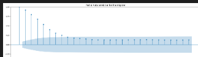

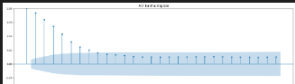

Smooth, monotonic decay

p ∈ {1,2,3,4}, d = 0, q ∈ {0}

**NonSpiderLangCommons**

1

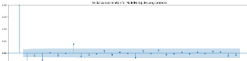

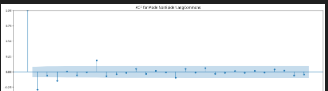

Clear cutoff at lag‑1

p ∈ {0,1,2}, d = 1, q ∈ {0,1}

**NonSpiderLangDe**

1

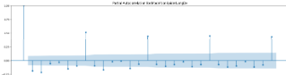

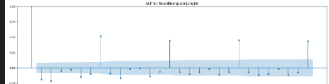

No cutoff; isolated higher‑lag spikes

p ∈ {0,1}, d = 1, q ∈ {0}

**NonSpiderLangEn**

1

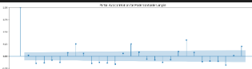

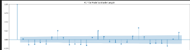

No cutoff; weak tailing

p ∈ {0,1}, d = 1, q ∈ {0,1}

**NonSpiderLangEs**

0

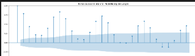

Isolated significant lags.  
Later lags (≈ 7, 14, 21, 28) are large,  
repeating spikes, roughly equally spaced.  
They are periodic / cyclical dependence  
leaking into PACF.  
What a true high‑order  
AR(p) PACF looks like -  
PACF is significant at lags 1…p,  
then drops to ~0 and stays there  
and No recurring structure.  
This was observed in  
ModelSpider above

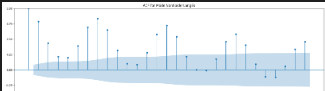

Oscillatory, no cutoff

p ∈ {0,1,2}, d = 0, q ∈ {0}

**NonSpiderLangFr**

0

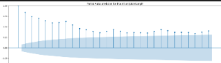

Gradual taper, no cutoff

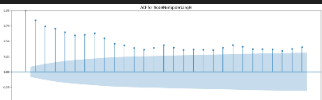

Gradual decay

p ∈ {0,1,2}, d = 0, q ∈ {0}

**NonSpiderLangJa**

1

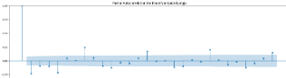

Strong negative lag‑1 only

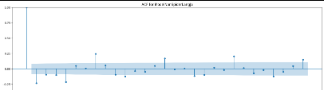

Clear cutoff at lag‑1

p ∈ {0,1,2}, d = 1, q ∈ {0,1}

**NonSpiderLangRu**

0

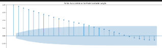

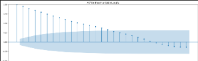

Smooth decay

p ∈ {1,2,3}, d = 0, q ∈ {0}

**NonSpiderLangWww**

0

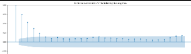

Significant lags 1–2

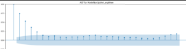

Fast decay, no cutoff (there is tailing, but no cutoff)

p ∈ {1,2,3}, d = 0, q ∈ {0}

**NonSpiderLangZh**

1

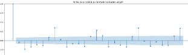

No clear low‑lag structure

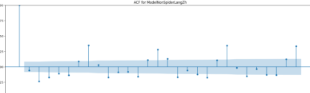

No cutoff; alternating small spikes

p ∈ {0,1}, d = 1, q ∈ {0}

**Summary** First differencing was applied to non‑stationary series until stationarity was confirmed via ADF testing. Autoregressive order was selected based on PACF cutoff behavior, while moving‑average order was informed by ACF tail behavior, resulting in low‑order ARIMA specifications for all segments.

## Setting up Train Test sets for model performance evaluation

let's create a function to estimate the performance of different models

```python
from sklearn.metrics import (
    mean_squared_error as mse,
    mean_absolute_error as mae,
    mean_absolute_percentage_error as mape
)

# Creating a function to print values of all these metrics.
def performance(actual, predicted,verbose=True):

    mape_val = round(mape(actual, predicted), 3)
    rmse_val = round(mse(actual, predicted)**0.5, 3)
    mae_val = round(mae(actual, predicted), 3)

    if(verbose):
        print('MAE :',mae_val)
        print('RMSE :', rmse_val)
        print('MAPE:', mape_val)
    return mape_val,rmse_val, mae_val
```

## Train Test Split

We can simply use **slicing** to obtain these sets.

```python
test_size=int(len(timeSeriesFull_df)*0.2)  #20% test
train_max_date = timeSeriesFull_df.index[-test_size]
train_max_date
```

```
Timestamp('2016-09-13 00:00:00')
```

```python
train_x = timeSeriesFull_df.loc[timeSeriesFull_df.index < train_max_date].copy()
test_x = timeSeriesFull_df.loc[timeSeriesFull_df.index >=train_max_date].copy()

test_x.head()
```

|  | ModelSpider | ModelNonSpiderLangCommons | ModelNonSpiderLangDe | ModelNonSpiderLangEn | ModelNonSpiderLangEs | ModelNonSpiderLangFr | ModelNonSpiderLangJa | ModelNonSpiderLangRu | ModelNonSpiderLangWww | ModelNonSpiderLangZh |
| --- | --- | --- | --- | --- | --- | --- | --- | --- | --- | --- |
| 2016-09-13 | 2.508016e+06 | 2.408625e+06 | 1.505150e+07 | 1.173980e+08 | 2.393244e+07 | 1.119424e+07 | 1.665876e+07 | 1.277009e+07 | 511121.761919 | 5.892740e+06 |
| 2016-09-14 | 2.288274e+06 | 2.700041e+06 | 1.473732e+07 | 1.167235e+08 | 2.086071e+07 | 1.127335e+07 | 1.516306e+07 | 1.305415e+07 | 509100.833758 | 6.812227e+06 |
| 2016-09-15 | 2.302830e+06 | 2.977628e+06 | 1.458530e+07 | 1.199807e+08 | 1.831930e+07 | 1.093425e+07 | 1.422972e+07 | 1.317330e+07 | 843732.000791 | 6.672931e+06 |
| 2016-09-16 | 2.423128e+06 | 3.361518e+06 | 1.465944e+07 | 1.017883e+08 | 1.552162e+07 | 1.052711e+07 | 1.403828e+07 | 1.262064e+07 | 397520.718835 | 7.233729e+06 |
| 2016-09-17 | 2.451582e+06 | 2.429943e+06 | 1.451717e+07 | 1.079524e+08 | 1.410321e+07 | 1.142064e+07 | 1.462078e+07 | 1.208457e+07 | 355179.722832 | 7.791701e+06 |

```python
len(test_x)
```

```
110
```

## Fitting ARIMA Model -------------------------------------

```python
from statsmodels.tsa.statespace.sarimax import SARIMAX

segmentName = modelNames[0]
model = SARIMAX(train_x[segmentName] ,order=(4,0,0),enforce_stationarity=False,
                                   enforce_invertibility=False)
model = model.fit(disp=False, maxiter=200)
```

### Fit on One series first and do a Performance Review

```
MAE : 2321531.651
RMSE : 2419872.336
MAPE: 0.896
```

```
(0.896, 2419872.336, 2321531.651)
```

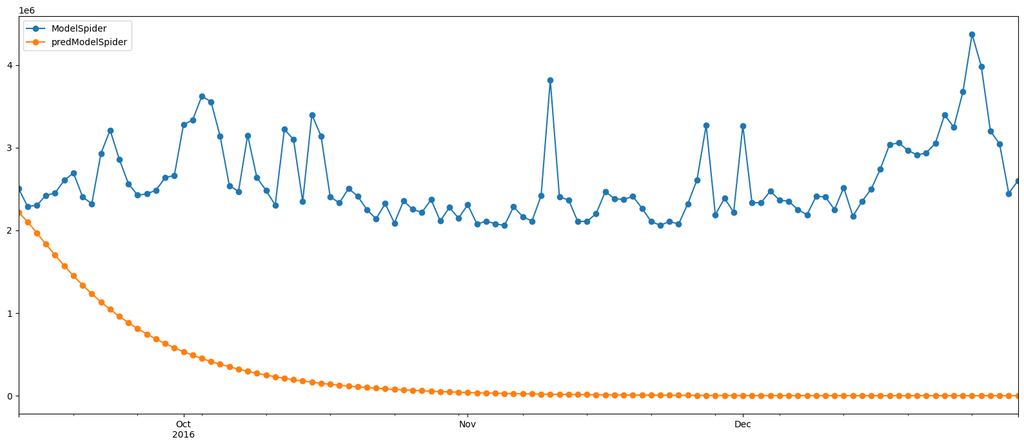

```python
predColumnName = 'pred'+segmentName

test_x[predColumnName] = model.forecast(steps=test_size)
test_x[[segmentName,predColumnName]].plot(style='-o')
performance(test_x[segmentName], test_x[predColumnName])
```

ARIMA is giving EXTREMELY poor results. Error (MAPE) is 89%

Our data has clear seasonality.

So should we spend time on ARIMA? To establish a baseline though, we will do a gridsearch using ARIMA for all models, and then try to improve on it.

### Define the ARIMA search space

This follows from our ACF PACF analysis.

```python
ARIMA_SEARCH_SPACE = {
    "ModelSpider": {
        "p": [1, 2, 3, 4],
        "d": [0],
        "q": [0],
        "P": [0],
        "D": [0],
        "Q": [0],
        "s": [0]
    },
    "ModelNonSpiderLangCommons": {
        "p": [0, 1, 2],
        "d": [1],
        "q": [0, 1],
        "P": [0],
        "D": [0],
        "Q": [0],
        "s": [0]
    },
    "ModelNonSpiderLangDe": {
        "p": [0, 1],
        "d": [1],
        "q": [0],
        "P": [0],
        "D": [0],
        "Q": [0],
        "s": [0]
    },
    "ModelNonSpiderLangEn": {
        "p": [0, 1],
        "d": [1],
        "q": [0, 1],
        "P": [0],
        "D": [0],
        "Q": [0],
        "s": [0]
    },
    "ModelNonSpiderLangEs": {
        "p": [0, 1, 2],
        "d": [0],
        "q": [0],
        "P": [0],
        "D": [0],
        "Q": [0],
        "s": [0]
    },
    "ModelNonSpiderLangFr": {
        "p": [0, 1, 2],
        "d": [0],
        "q": [0],
        "P": [0],
        "D": [0],
        "Q": [0],
        "s": [0]
    },
    "ModelNonSpiderLangJa": {
        "p": [0, 1, 2],
        "d": [1],
        "q": [0, 1],
        "P": [0],
        "D": [0],
        "Q": [0],
        "s": [0]
    },
    "ModelNonSpiderLangRu": {
        "p": [1, 2, 3],
        "d": [0],
        "q": [0],
        "P": [0],
        "D": [0],
        "Q": [0],
        "s": [0]
    },
    "ModelNonSpiderLangWww": {
        "p": [1, 2, 3],
        "d": [0],
        "q": [0],
        "P": [0],
        "D": [0],
        "Q": [0],
        "s": [0]
    },
    "ModelNonSpiderLangZh": {
        "p": [0, 1],
        "d": [1],
        "q": [0],
        "P": [0],
        "D": [0],
        "Q": [0],
        "s": [0]
    }
}

ARIMA_SEARCH_SPACE_old = {
    "ModelSpider": {
        "p": [1, 2, 3, 4],
        "d": [0],
        "q": [0],
        "P": [0],
        "D": [0],
        "Q": [0],
        "s": [0],
        "numExog": 0
    },
    "ModelNonSpiderLangCommons": {
        "p": [0, 1, 2],
        "d": [1],
        "q": [0, 1],
        "P": [0],
        "D": [0],
        "Q": [0],
        "s": [0],
        "numExog": 0
    },
    "ModelNonSpiderLangDe": {
        "p": [0, 1],
        "d": [1],
        "q": [0],
        "P": [0],
        "D": [0],
        "Q": [0],
        "s": [0],
        "numExog": 0
    },
    "ModelNonSpiderLangEn": {
        "p": [0, 1],
        "d": [1],
        "q": [0, 1],
        "P": [0],
        "D": [0],
        "Q": [0],
        "s": [0],
        "numExog": 0
    },
    "ModelNonSpiderLangEs": {
        "p": [0, 1, 2],
        "d": [0],
        "q": [0],
        "P": [0],
        "D": [0],
        "Q": [0],
        "s": [0],
        "numExog": 0
    },
    "ModelNonSpiderLangFr": {
        "p": [0, 1, 2],
        "d": [0],
        "q": [0],
        "P": [0],
        "D": [0],
        "Q": [0],
        "s": [0],
        "numExog": 0
    },
    "ModelNonSpiderLangJa": {
        "p": [0, 1, 2],
        "d": [1],
        "q": [0, 1],
        "P": [0],
        "D": [0],
        "Q": [0],
        "s": [0],
        "numExog": 0
    },
    "ModelNonSpiderLangRu": {
        "p": [1, 2, 3],
        "d": [0],
        "q": [0],
        "P": [0],
        "D": [0],
        "Q": [0],
        "s": [0],
        "numExog": 0
    },
    "ModelNonSpiderLangWww": {
        "p": [1, 2, 3],
        "d": [0],
        "q": [0],
        "P": [0],
        "D": [0],
        "Q": [0],
        "s": [0],
        "numExog": 0
    },
    "ModelNonSpiderLangZh": {
        "p": [0, 1],
        "d": [1],
        "q": [0],
        "P": [0],
        "D": [0],
        "Q": [0],
        "s": [0],
        "numExog": 0
    }
}
```

### Grid‑search function (MAPE + AIC + BIC)

- We want to write ONE function that can do ARIMA, SARIMA and SARIMAX
- It takes the order ranges and ONE series
- Returns best result
- Saves the find in our modelDict object (MLOps to keep track of all experiments.)

```python
from statsmodels.tsa.statespace.sarimax import SARIMAX
import warnings
import numpy as np
import pandas as pd
from itertools import product
import time

def gridSearchSARIMAX(y, space, exog_df=pd.DataFrame(),
                      train_ratio=0.8, metric='mape', verbose=True):
    """
    Grid search for optimal SARIMAX parameters on a single series.

    Parameters:
    -----------
    y : array-like - Time series data
    p_range : list/range - AR orders to try (e.g., [0, 1, 2])
    d_range : list/range - Differencing orders (e.g., [0, 1])
    q_range : list/range - MA orders (e.g., [0, 1, 2])
    P_range : list/range - Seasonal AR orders
    D_range : list/range - Seasonal differencing orders
    Q_range : list/range - Seasonal MA orders
    s : int - Seasonal period (default 7 for weekly)
    exogSeries: Exogeneous regressor series.
    train_ratio : float - Train/test split ratio
    metric : str - 'mape', 'aic', 'bic', or 'rmse'
    verbose : bool - Print progress

    Returns:
    --------
    results_df : DataFrame with all combinations and scores
    best_params : dict with best parameters
    """



    # Train/test split
    n = len(y)
    train_size = int(n * train_ratio)
    y_train = y[:train_size]
    y_test = y[train_size:]
    if(exog_df is None or len(exog_df.columns)==0):
        exog_train=None
        exog_test=None
        exog_cols=''
    else:
        exog_train = exog_df[:train_size]
        exog_test = exog_df[train_size:]
        exog_cols= exog_train.columns

    # Generate all combinations
    import math;
    total_combinations = math.prod(len(v) for v in space.values())

    #Always printed text, even with Verbose=False
    print(f"Testing {total_combinations} combinations...")

    if verbose:
        # print(f"Testing {total_combinations} combinations...")
        print(f"Train size: {train_size}, Test size: {len(y_test)}")

    results = []
    tested = 0

    for p in space["p"]:
        for d in space["d"]:
            for q in space["q"]:
                for P in space["P"]:
                    for D in space["D"]:
                        for Q in space["Q"]:
                            for s in space["s"]:
                                tested += 1
                                try:
                                    with warnings.catch_warnings():
                                        warnings.simplefilter("ignore")

                                        # Fit model
                                        model = SARIMAX(endog=y_train,
                                                    order=(p, d, q),
                                                    seasonal_order=(P, D, Q, s),
                                                    exog=exog_train,
                                                    enforce_stationarity=False,
                                                    enforce_invertibility=False)

                                        fitted = model.fit(disp=False, maxiter=200)

                                        # Forecast
                                        forecast = fitted.forecast(steps=len(y_test), exog=exog_test)

                                        # Calculate metrics
                                        mape,rmse, mae = performance(y_test, forecast, verbose=False)
                                        results.append({
                                            'order': f'{p,d,q}',
                                            'seasonal_order':  f'{(P, D, Q, s)}',
                                            'exog': exog_cols,
                                            'aic': fitted.aic,
                                            'bic': fitted.bic,
                                            'mape': mape,
                                            'rmse': rmse,
                                            'mae': mae,
                                            'converged': True
                                        })

                                        if verbose and tested % 20 == 0:
                                            print(f"  Progress: {tested}/{total_combinations} ({100*tested/total_combinations:.1f}%)")

                                except Exception as e:
                                    results.append({
                                        'order': f'({p,d,q})',
                                        'seasonal_order':  f'({(P, D, Q, s)})',
                                        'aic': np.nan, 'bic': np.nan,
                                        'mape': np.nan, 'rmse': np.nan, 'mae': np.nan,
                                        'converged': False,
                                        'error': str(e)
                                    })

    # Create results DataFrame
    results_df = pd.DataFrame(results)

    # Find best parameters
    if metric == 'mape':
        best_idx = results_df['mape'].idxmin()
    elif metric == 'aic':
        best_idx = results_df['aic'].idxmin()
    elif metric == 'bic':
        best_idx = results_df['bic'].idxmin()
    elif metric == 'rmse':
        best_idx = results_df['rmse'].idxmin()
    else:
        best_idx = results_df['mape'].idxmin()

    best_row = results_df.loc[best_idx]
    best_params = {
        'order': best_row['order'],
        'seasonal_order': best_row['seasonal_order'],
        'exog': exog_cols,
        'mape': best_row['mape'],
        'aic': best_row['aic'],
        'bic': best_row['bic'],
        'rmse': best_row['rmse']
    }
    #Always printed text, even with Verbose=False
    print("MAPE:",best_row['mape'])


    if verbose:
        print(f"\n✅ Best by {metric.upper()}:")
        print(f"   Order: {best_params['order']}")
        print(f"   Seasonal: {best_params['seasonal_order']}")
        print(f"   MAPE: {best_params['mape']:.2f}%")
        print(f"   AIC: {best_params['aic']:.2f}")

    return results_df, best_params
```

Lets try our grid search function on same series what we used in direct ARIMA to see if it works correctly

```python
#Lets try same series what we used in direct ARIMA
segmentName = modelNames[0]
# ARIMA_SEARCH_SPACE = {
#     "ModelSpider": {
#         "p": [1, 2, 3, 4],
#         "d": [0],
#         "q": [0]
#     }
r,b = gridSearchSARIMAX(timeSeriesFull_df[segmentName] ,
                        ARIMA_SEARCH_SPACE[segmentName])
r
```

```
Testing 4 combinations...
Train size: 440, Test size: 110
MAPE: 0.738

✅ Best by MAPE:
   Order: (1, 0, 0)
   Seasonal: (0, 0, 0, 0)
   MAPE: 0.74%
   AIC: 13080.64
```

|  | order | seasonal_order | exog | aic | bic | mape | rmse | mae | converged |
| --- | --- | --- | --- | --- | --- | --- | --- | --- | --- |
| 0 | (1, 0, 0) | (0, 0, 0, 0) |  | 13080.635490 | 13088.804489 | 0.738 | 2063068.249 | 1922742.330 | True |
| 1 | (2, 0, 0) | (0, 0, 0, 0) |  | 13016.211772 | 13028.458428 | 0.859 | 2333037.461 | 2225966.750 | True |
| 2 | (3, 0, 0) | (0, 0, 0, 0) |  | 12989.504100 | 13005.823833 | 0.858 | 2331361.613 | 2224083.772 | True |
| 3 | (4, 0, 0) | (0, 0, 0, 0) |  | 12954.296060 | 12974.684272 | 0.896 | 2419872.336 | 2321531.651 | True |

- We tried (4,0,0) manually and using gridsearch, got 89%, so grid search code is correct.

### gridSearchARIMAAllSegments()

```python
def gridSearchSARIMAXAllSegments(timeSeriesCombined_df, modelNames, modelDict, searchSpace, exog_all_segments_df=None,
                          train_ratio=0.8,metric='mape', searchTitle="GridSearch", comments="GridSearch",verbose=True):
    """
    Run grid search on all segments.
    exogSeries_df- pass in a dataframe that has column named segment_exog_[i] for the segment for which we want to apply exogeneous regressor
    We want to support unlimilted exogeneus columns.  So for that we have the [i]
    * If a segment has two exogeneous columns, then we will have <segment_name>_exog_1 and <segment_name>_exog_2
    * If a segment has one exogeneous columns, then we will have <segment_name>_exog_1
    * If a segment has no exogeneous columns, then we will have no column that has <segment_name>_exog*
    * Number of columns will come from searchSpace grid.



    Returns:
    --------
    all_results : dict with results for each segment
    best_orders : dict with best parameters for each segment
    """

    all_results = {}
    best_orders = {}
    exog_segment_df=pd.DataFrame()
    exog_segment_cols=[]

    for i, segmentName in enumerate(modelNames):
        print(f"\n{'='*60}")
        print(f"GRID SEARCH: {segmentName}")
        print(f"{'='*60}")

        if(exog_all_segments_df is not None):
            # find all exogenous columns for this segment
            exog_segment_cols = [col for col in exog_all_segments_df.columns if col.startswith(f"{segmentName}_exog")]
            exog_segment_df = exog_all_segments_df[exog_segment_cols]

        else:
            exog_segment_df=None

        # Run grid search
        start_time = time.time()
        results_df, best_params = gridSearchSARIMAX(timeSeriesCombined_df[segmentName] ,
                                 searchSpace[segmentName],exog_df=exog_segment_df,
                                 train_ratio=train_ratio, metric=metric, verbose=verbose)

        elapsed = time.time() - start_time
        print(f"  ⏱️ Time: {elapsed:.1f} seconds")

        # Store results
        all_results[segmentName] = results_df
        best_orders[segmentName] = best_params

        # Log best model to modelDict
        addModelAttempt(
            modelDict, segmentName,
            searchTitle,
            (best_params['order'], best_params['seasonal_order'],exog_segment_cols),
            best_params['mape'],
            comments=f"{comments} | AIC:{best_params['aic']:.1f}",
            verbose=verbose

        )

    return all_results, best_orders
```

```python
printModelDictSummaryDETAILED(showAttempts=True)
```

**Model Dictionary Summary**

| Model Name | Data Rows | # Attempts | Best Model | Best Params | Best MAPE |
| --- | --- | --- | --- | --- | --- |

| ModelSpider | 34913 | 0 | None | - | - | ModelNonSpiderLangCommons | 8005 | 0 | None | - | - | ModelNonSpiderLangDe | 13960 | 0 | None | - | - | ModelNonSpiderLangEn | 19177 | 0 | None | - | - | ModelNonSpiderLangEs | 10532 | 0 | None | - | - | ModelNonSpiderLangFr | 13302 | 0 | None | - | - | ModelNonSpiderLangJa | 15424 | 0 | None | - | - | ModelNonSpiderLangRu | 11280 | 0 | None | - | - | ModelNonSpiderLangWww | 5551 | 0 | None | - | - | ModelNonSpiderLangZh | 12919 | 0 | None | - | - | **TOTAL** | **145063** | **0** | - | - | - |

**Validation**

| Metric | Count |
| --- | --- |
| Total rows across models | 145063 |
| Original dataframe rows | 145063 |
| Difference | 0 |

✅ **MATCH:** Total rows equals original dataframe!

**Best MAPE Ranking**

| Rank | Segment Name | Best MAPE |Source |------|------------|-----------|------| | - | No models fitted yet | - |

```python
r,b=gridSearchSARIMAXAllSegments(timeSeriesCombined_df=timeSeriesFull_df,
                                modelNames=modelNames,
                                modelDict=modelDict,
                                searchSpace=ARIMA_SEARCH_SPACE,
                                exog_all_segments_df=None,
                                train_ratio=0.8,
                                metric='mape',
                                searchTitle="ARIMA GridSearch",
                                comments="Used ARIMA_SEARCH_SPACE",
                                verbose=False)
```

```
============================================================
GRID SEARCH: ModelSpider
============================================================
Testing 4 combinations...
MAPE: 0.738
  ⏱️ Time: 0.2 seconds

============================================================
GRID SEARCH: ModelNonSpiderLangCommons
============================================================
Testing 6 combinations...
MAPE: 0.147
  ⏱️ Time: 0.2 seconds

============================================================
GRID SEARCH: ModelNonSpiderLangDe
============================================================
Testing 2 combinations...
MAPE: 0.074
  ⏱️ Time: 0.0 seconds

============================================================
GRID SEARCH: ModelNonSpiderLangEn
============================================================
Testing 4 combinations...
MAPE: 0.069
  ⏱️ Time: 0.1 seconds

============================================================
GRID SEARCH: ModelNonSpiderLangEs
============================================================
Testing 3 combinations...
MAPE: 0.181
  ⏱️ Time: 0.1 seconds

============================================================
GRID SEARCH: ModelNonSpiderLangFr
============================================================
Testing 3 combinations...
MAPE: 0.117
```

[output cut: 14 more lines]

```
  ⏱️ Time: 0.1 seconds

============================================================
GRID SEARCH: ModelNonSpiderLangWww
============================================================
Testing 3 combinations...
MAPE: 0.786
  ⏱️ Time: 0.1 seconds

============================================================
GRID SEARCH: ModelNonSpiderLangZh
============================================================
Testing 2 combinations...
MAPE: 0.065
  ⏱️ Time: 0.0 seconds
```

```python
printModelDictSummaryDETAILED(showAttempts=True)
```

**Model Dictionary Summary**

| Model Name | Data Rows | # Attempts | Best Model | Best Params | Best MAPE |
| --- | --- | --- | --- | --- | --- |

| ModelSpider | 34913 | 1 | ARIMA GridSearch | ('(1, 0, 0)', '(0, 0, 0, 0)', []) | 0.7380% | ↳ Attempts: | | | | | | | 1. ARIMA GridSearch('(1, 0, 0)', '(0, 0, 0, 0)', []) | | | | 73.8% | Used ARIMA_SEARCH_SPACE | AIC:... | | ModelNonSpiderLangCommons | 8005 | 1 | ARIMA GridSearch | ('(0, 1, 0)', '(0, 0, 0, 0)', []) | 0.1470% | ↳ Attempts: | | | | | | | 1. ARIMA GridSearch('(0, 1, 0)', '(0, 0, 0, 0)', []) | | | | 14.7% | Used ARIMA_SEARCH_SPACE | AIC:... | | ModelNonSpiderLangDe | 13960 | 1 | ARIMA GridSearch | ('(0, 1, 0)', '(0, 0, 0, 0)', []) | 0.0740% | ↳ Attempts: | | | | | | | 1. ARIMA GridSearch('(0, 1, 0)', '(0, 0, 0, 0)', []) | | | | 7.4% | Used ARIMA_SEARCH_SPACE | AIC:... | | ModelNonSpiderLangEn | 19177 | 1 | ARIMA GridSearch | ('(0, 1, 0)', '(0, 0, 0, 0)', []) | 0.0690% | ↳ Attempts: | | | | | | | 1. ARIMA GridSearch('(0, 1, 0)', '(0, 0, 0, 0)', []) | | | | 6.9% | Used ARIMA_SEARCH_SPACE | AIC:... | | ModelNonSpiderLangEs | 10532 | 1 | ARIMA GridSearch | ('(1, 0, 0)', '(0, 0, 0, 0)', []) | 0.1810% | ↳ Attempts: | | | | | | | 1. ARIMA GridSearch('(1, 0, 0)', '(0, 0, 0, 0)', []) | | | | 18.1% | Used ARIMA_SEARCH_SPACE | AIC:... | | ModelNonSpiderLangFr | 13302 | 1 | ARIMA GridSearch | ('(2, 0, 0)', '(0, 0, 0, 0)', []) | 0.1170% | ↳ Attempts: | | | | | | | 1. ARIMA GridSearch('(2, 0, 0)', '(0, 0, 0, 0)', []) | | | | 11.7% | Used ARIMA_SEARCH_SPACE | AIC:... | | ModelNonSpiderLangJa | 15424 | 1 | ARIMA GridSearch | ('(0, 1, 1)', '(0, 0, 0, 0)', []) | 0.0880% | ↳ Attempts: | | | | | | | 1. ARIMA GridSearch('(0, 1, 1)', '(0, 0, 0, 0)', []) | | | | 8.8% | Used ARIMA_SEARCH_SPACE | AIC:... | | ModelNonSpiderLangRu | 11280 | 1 | ARIMA GridSearch | ('(1, 0, 0)', '(0, 0, 0, 0)', []) | 0.3210% | ↳ Attempts: | | | | | | | 1. ARIMA GridSearch('(1, 0, 0)', '(0, 0, 0, 0)', []) | | | | 32.1% | Used ARIMA_SEARCH_SPACE | AIC:... | | ModelNonSpiderLangWww | 5551 | 1 | ARIMA GridSearch | ('(1, 0, 0)', '(0, 0, 0, 0)', []) | 0.7860% | ↳ Attempts: | | | | | | | 1. ARIMA GridSearch('(1, 0, 0)', '(0, 0, 0, 0)', []) | | | | 78.6% | Used ARIMA_SEARCH_SPACE | AIC:... | | ModelNonSpiderLangZh | 12919 | 1 | ARIMA GridSearch | ('(1, 1, 0)', '(0, 0, 0, 0)', []) | 0.0650% | ↳ Attempts: | | | | | | | 1. ARIMA GridSearch('(1, 1, 0)', '(0, 0, 0, 0)', []) | | | | 6.5% | Used ARIMA_SEARCH_SPACE | AIC:... | | **TOTAL** | **145063** | **10** | - | - | - |

**Validation**

| Metric | Count |
| --- | --- |
| Total rows across models | 145063 |
| Original dataframe rows | 145063 |
| Difference | 0 |

✅ **MATCH:** Total rows equals original dataframe!

**Best MAPE Ranking**

| Rank | Segment Name | Best MAPE |Source |------|------------|-----------|------| | 1 | ModelNonSpiderLangZh | 6.5% |ARIMA GridSearch('(1, 1, 0)', '(0, 0, 0, 0)', []) | 2 | ModelNonSpiderLangEn | 6.9% |ARIMA GridSearch('(0, 1, 0)', '(0, 0, 0, 0)', []) | 3 | ModelNonSpiderLangDe | 7.4% |ARIMA GridSearch('(0, 1, 0)', '(0, 0, 0, 0)', []) | 4 | ModelNonSpiderLangJa | 8.8% |ARIMA GridSearch('(0, 1, 1)', '(0, 0, 0, 0)', []) | 5 | ModelNonSpiderLangFr | 11.7% |ARIMA GridSearch('(2, 0, 0)', '(0, 0, 0, 0)', []) | 6 | ModelNonSpiderLangCommons | 14.7% |ARIMA GridSearch('(0, 1, 0)', '(0, 0, 0, 0)', []) | 7 | ModelNonSpiderLangEs | 18.1% |ARIMA GridSearch('(1, 0, 0)', '(0, 0, 0, 0)', []) | 8 | ModelNonSpiderLangRu | 32.1% |ARIMA GridSearch('(1, 0, 0)', '(0, 0, 0, 0)', []) | 9 | ModelSpider | 73.8% |ARIMA GridSearch('(1, 0, 0)', '(0, 0, 0, 0)', []) | 10 | ModelNonSpiderLangWww | 78.6% |ARIMA GridSearch('(1, 0, 0)', '(0, 0, 0, 0)', [])

## Checking for Seasonality

- ARIMA did not utilize seasonality.
- But if its there, it can be taken into consideration as it will help us improve our model
- Lets decompose our series to see trend , seasonality

### Plot Seasonal decomposition of one sample

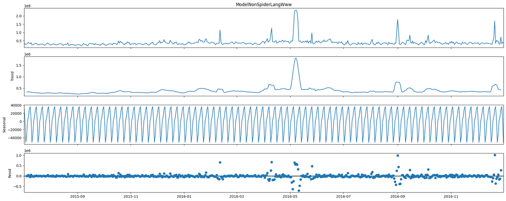

```python
import statsmodels.api as sm


decompose_model = sm.tsa.seasonal_decompose(timeSeriesFull_differenced_df[modelNames[8]], model='additive')
decompose_model.plot();
```

- We are having STRONG seasonality !!
- But ADF test indicated stationary series. Is there a contradiction here?
- The key point is:

### **ADF stationarity ≠ “no trend or no seasonality”**

**1️⃣ What the ADF test actually checks (very important)**

ADF tests **only one thing**:

> **Is there a unit root (stochastic trend)?**
- **p < 0.05** ⇒ **no unit root**
- That means the series is **mean-reverting**
- It does **NOT** mean:
  - no trend
  - no seasonality
  - no spikes
  - no structure

📌 A series **can be stationary AND seasonal**

📌 A series **can be stationary AND have level shifts / spikes**

Here is why a series can be "stationary" according to the ADF test while still having visible patterns:

**1. Stationary AND Seasonal**

A series is stationary if its mean, variance, and autocorrelation structure do not change over time.

- **The Logic:** If a series has a seasonal pattern (e.g., electricity demand peaks every 24 hours) but that pattern is **constant and predictable**, the series is often considered "seasonally stationary."
- **Mean Reversion:** Even with seasonality, the series constantly pulls back toward a long-term average or a repeating cycle. It doesn't "drift away" forever like a random walk would.

**2. Stationary AND Level Shifts / Spikes**

The ADF test checks if a shock to the system lasts forever.

- **The "Shock" Test:** In a non-stationary series (like a Random Walk), if the price jumps by $10, that $10 increase is permanent. In a stationary series, if there is a massive "spike," the system eventually pulls the value back to its mean.
- **Structure:** You can have a series that is mostly flat but has occasional, violent spikes. As long as those spikes are short-lived and the series returns to its average, the ADF test will still call it stationary.

**3. The Difference: Stochastic vs. Deterministic Trends**

This is the most important distinction for understanding that image:

- **Stochastic Trend (Unit Root):** The "drift" is random. The series wanders aimlessly and never returns to a baseline. **ADF catches this.**
- **Deterministic Trend:** The series follows a predictable path (like a straight line up or a sine wave). While it's not "strictly" stationary, it is "trend-stationary." You can subtract the trend/seasonality, and you are left with a perfectly stationary series.

**ARIMA versus SARIMA**

➡️ **SARIMA can give better** results for this data.

### Determining Seasonality length

- Before we try fit a SARIMA model, lets see if we can "see" the seasonality in data
- The Seasonal decompose plot shows a very very compressed view, so while its clear there is a seasonality, we cannot really "read it off" from the plot just yet
- The decompose_model provides access to seasonal component using `decompose_model.seasonal`. But this is just a repeated seasonal signal, we still need to infer/caculate the seasonality length
- Lets look at our series more closely to "see" the seasonality trend

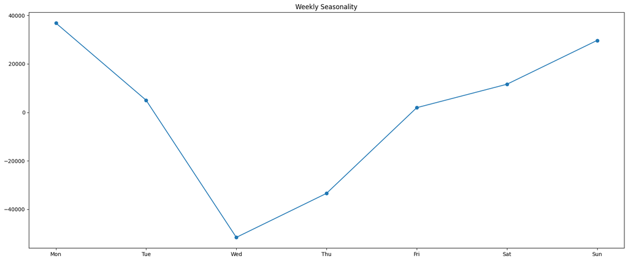

```python
#Extract the time series called seasonal from the decompose model.
seasonal = decompose_model.seasonal

#Lets plot just one week
one_week = seasonal.iloc[:7]
one_week.index = ['Mon','Tue','Wed','Thu','Fri','Sat','Sun']
one_week.plot(marker='o', title='Weekly Seasonality')
```

- **Interesting result.** We can "see" there is some movement.
- But does it repeat.
- Lets plot a broader window, say 28 days.

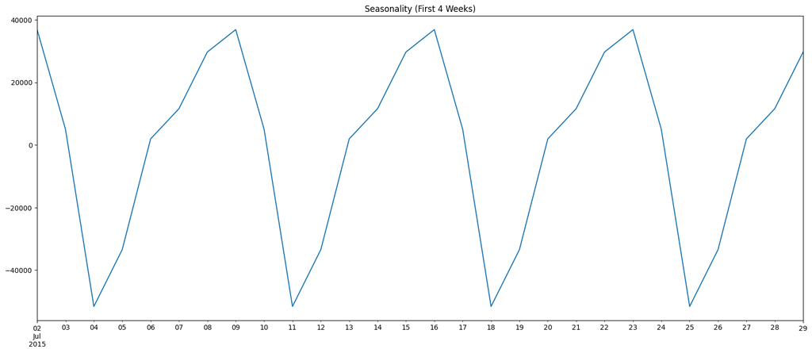

```python
seasonal.iloc[:28].plot(title='Seasonality (First 4 Weeks)')
```

- In 28 days too, we can see a trend that repeats 4 times. **This is strong hint that our seasonality is 7 days.**
- This is visual proof, but not mathematical. We are not concluding it just yet.
- But we do have solid ground to say that the cycle could be 7 days (Wikipedia pages are things people will read every week)
- A mathematical proof will be if the pattern is same across all weeks. What if we saw all 7 day weeks and averaged out the values.
- That is what we do next. Lets average across all cycles to remove any noise

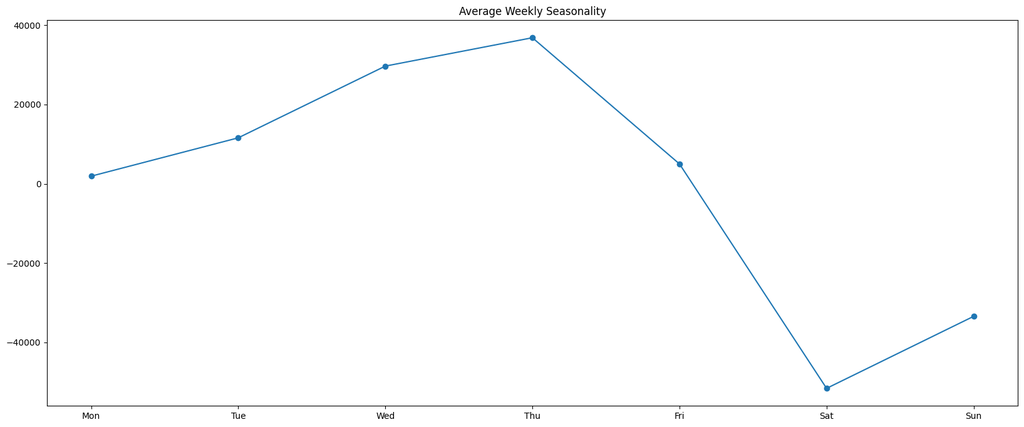

```python
weekly_seasonality = (
    seasonal
    .groupby(seasonal.index.dayofweek)
    .mean()
)

weekly_seasonality.index = ['Mon','Tue','Wed','Thu','Fri','Sat','Sun']

weekly_seasonality.plot(marker='o', title='Average Weekly Seasonality')
```

Clear weekly seasonality exists ✅ The curve is not flat and shows a strong, consistent pattern by day of week.

**Intepreting this graph**

**Mid‑week peak (Wed–Thu)**

**Observations**

- **Thursday is the strongest positive day**
- Wednesday is a close second
- Tuesday is moderately positive
- Monday is barely above baseline

**Interpretation**

- Demand / activity **builds through the workweek**
- Peaks **before the weekend**
- Suggests:
  - Business-driven behavior
  - Planning / decision-making mid-week

✅ **Modeling implication**

- SARIMA with weekly seasonality is appropriate
- Exogenous regressors like “weekday dummies” would help

```
pd.get_dummies(ts.index.dayofweek, drop_first=True)
```

This will:

- Explicitly model the weekend crash
- Reduce seasonal burden on SARIMA terms

**Magnitude is large → seasonality dominates noise**

The seasonal effect ranges roughly:

- **+35k at peak**
- **−50k at trough**

That’s a **~85k swing weekly**.

➡️ Seasonality is not subtle — it’s a **primary driver**.

## Business-level interpretation

- Users are **work‑week oriented**
- Thursday is the most valuable day
- Saturday is nearly “dead time”
- Forecast errors will spike on weekends if not modeled properly

### Plot Seasonal Decomposition for all Segments

**One question - should we pass period or not.**

**Short answer (rule)**

✅ **You SHOULD pass `period`**  
❌ **Not passing it does NOT let the model “figure it out”**

In fact:

> **If you don’t pass `period`, `seasonal_decompose` is either guessing poorly or will fail.**

**Why this is the case**

`seasonal_decompose` in **statsmodels** is **not a learning algorithm**.  
It does **not infer seasonality** from the data. It does **NOT** “try multiple periods and choose the best one”.

Instead, it:

- **assumes a fixed season length**
- then mechanically splits the series into:
  - trend (via moving average)
  - seasonal (average of aligned positions)
  - residual

So when you pass `period`, you’re not *biasing* it — you’re giving it **required structural information**.

**Analogy (important intuition)**

Think of `period` like this:

> Passing `period=7` is like saying  
> *“This is daily data, check if there’s a weekly pattern.”*

Not:

> *“Force weekly seasonality no matter what.”*

If there is **no weekly seasonality**, the seasonal component will be close to zero.

**Best practice - Detect candidate periods outside decomposition**

Use **domain knowledge first**:

- Daily data → try `7`
- Monthly data → try `12`
- Hourly data → try `24`, `168`

**We did this.

- From ACF and PACF plot, we can infer period = 7.
- Also our data is daily data.
- Also, in next section, we plotted weekly means and again can confirm there is 7 day seasonality

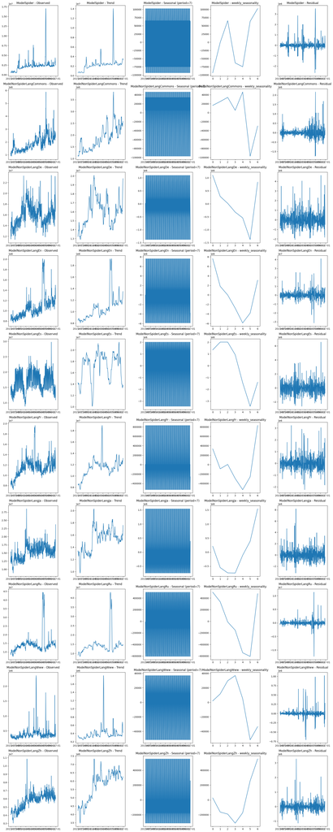

```python
from statsmodels.tsa.seasonal import seasonal_decompose
import matplotlib.pyplot as plt

def plotSeasonalDecomposition(timeSeriesCombined_df, modelNames, period=7):
    """
    Plot seasonal decomposition for all segments.
    """
    fig, axes = plt.subplots(len(timeSeriesCombined_df.columns), 5, figsize=(20, 5*len(timeSeriesCombined_df.columns)))

    for i,model in enumerate(modelNames):
        ts = timeSeriesCombined_df[model]

        try:
            decomposition = seasonal_decompose(ts, model='additive', period=period)

            axes[i, 0].plot(decomposition.observed)
            axes[i, 0].set_title(f'{model} - Observed')

            axes[i, 1].plot(decomposition.trend)
            axes[i, 1].set_title(f'{model} - Trend')

            axes[i, 2].plot(decomposition.seasonal)
            axes[i, 2].set_title(f'{model} - Seasonal (period={period})')

            weekly_seasonality = (
                decomposition.seasonal
                .groupby(decomposition.seasonal.index.dayofweek)
                .mean()
            )
            # weekly_seasonality.index = ['Mon','Tue','Wed','Thu','Fri','Sat','Sun']
            # weekly_seasonality.plot(marker='o', title='Average Weekly Seasonality', axes=axes[i, 3])


            axes[i, 3].plot(weekly_seasonality)
            axes[i, 3].set_title(f'{model} - weekly_seasonality')

            axes[i, 4].plot(decomposition.resid)
            axes[i, 4].set_title(f'{model} - Residual')

        except Exception as e:
            axes[i, 0].text(0.5, 0.5, f'Error: {e}', ha='center')
            axes[i, 0].set_title(f'{model} - Error')

    plt.tight_layout()
    plt.show()

#We do seasonal_decompose on the original (non‑differenced) series, not the differenced one.
plotSeasonalDecomposition(timeSeriesFull_df, modelNames, period=7)
```

**Big Picture (Across All Segments)**

- ✅ 1. Weekly seasonality exists in **every segment**
  - Even though the *shape* differs, **none of the weekly_seasonality plots are flat**.
  - ➡️ This justifies:
    - `s = 7` **globally**
    - At least considering `D = 1` for most segments
- ✅ 2. Seasonality is **asymmetric**, not sinusoidal
  - Across segments:
    - Gradual buildup during weekdays
    - Sharp drop around Fri–Sat
    - Partial recovery on Sunday
  - ➡️ This is **behavioral seasonality**, not a smooth cycle.
  - **Implication**
    - SARIMA alone may struggle
    - SARIMAX + weekday exogenous variables will perform better
- Residual Diagnostics (What to Notice)
  - Across most segments:
    - Residuals are centered around zero ✅
    - Variance spikes remain ❌
  - Meaning
    - Weekly seasonality explains structure
    - But **exogenous shocks remain**

Segment-Level Insights

**1️⃣ ModelSpider (Crawler traffic)**

**What we see**

**Interpretation**

✅ **Modeling choice**

**2️⃣ NonSpiderLangCommons / En / De / Fr / Es (Human traffic)**

**What we see**

**Interpretation**

- Human usage is **business-day driven**
- Predictable, stable behavior

✅ **Modeling choice**

- SARIMAX with:
  - `s = 7`, `D = 1`
  - Weekday dummies as exog
- Lower AR/MA complexity needed once exog is added

**3️⃣ Asian languages (Ja, Zh)**

**What we see**

- Still weekly seasonality
- Shape slightly shifted (earlier/later peaks)
- Weekend drop exists but may differ in depth

**Interpretation**

- Cultural/workweek differences
- Same cycle length, different profile

✅ **Modeling choice**

- `s = 7`, `D = 1`
- Weekday exog still valid
- Do **not** assume same coefficients as EN/FR

**4️⃣ WWW / Ru (noisier segments)**

**What we see**

- Weekly shape exists but noisier
- Trend is less smooth
- Residuals have more spikes

**Interpretation**

- Mixed traffic sources
- External shocks (events, bots, releases)

✅ **Modeling choice**

- SARIMAX with:
  - `s = 7`
  - Possibly `D = 0` (test both)
- Exog helps stabilize forecasts

**Summary**

> “All segments show strong but asymmetric weekly seasonality with a sharp weekend drop, justifying `s=7` globally and favoring SARIMAX models with weekday exogenous regressors over purely seasonal AR terms.”

> ✅ Per-segment tuning

| Segment Type | D | Exog |
| --- | --- | --- |

Spider | 1 | No | Human language | 1 | Yes (weekday) | Noisy/mixed | 0–1 (test) | Yes |

## ACF and PACF for seasonally differenced data

**Do we need to do it?**

- We already know seasonality. From our decomposition:
  - s = 7 ✅
  - Weekly pattern ✅
  - Often needs D = 1 ✅
  - ACF/PACF won’t tell you anything new here.
- ACF PACF are mostly exploratory. I could have used them them when:
  - We want to shrink the grid
  - We’re modeling one series only
  - We need a quick exploratory check

We will straightaway do a grid search after carefully setting the grid search space.

## Fitting SARIMA model -------------------------------------

Seasonal AR/MA kept minimal (P≤1, Q=0) because:

- Weekly seasonality removed via D=1. That removes:
  - the mean weekly pattern
  - most weekly persistence
  - What remains is weak residual seasonality.
  - **➡️ One seasonal AR term (P=1) is enough to mop up what’s left.**
  - Higher P causes over‑coupling across weeks
    - P=2 means we are saying this week depends on the last TWO weeks
    - But our plots show strong weekday pattern
- No strong residual seasonal autocorrelation,
- Q competes with exogenous regressors.
  - We are already planning for addding weekday effects (explicit) and maybe events later
  - Seasonal MA then becomes redundant.
  - **➡️so Q=0**
- Why not let grid search decide everything?
  - Because SARIMA is **not convex**:
    - Many local minima
    - Many invalid models
    - AIC comparisons become noisy
    - Constraining the grid is a modeling decision, not laziness.
    - However if improvement is not there for some segments, we can consider expanding the grid in a controlled manner for those segments

```python
SARIMA_SEARCH_SPACE = {
    "ModelSpider": {
        "p": [1, 2, 3],
        "d": [0],
        "q": [0],
        "P": [0, 1],
        "D": [0],
        "Q": [0],
        "s": [7]
    },
    "ModelNonSpiderLangCommons": {
        "p": [0, 1, 2],
        "d": [1],
        "q": [0, 1],
        "P": [0, 1],
        "D": [1],
        "Q": [0],
        "s": [7]
    },
    "ModelNonSpiderLangDe": {
        "p": [0, 1],
        "d": [1],
        "q": [0],
        "P": [0, 1],
        "D": [1],
        "Q": [0],
        "s": [7]
    },
    "ModelNonSpiderLangEn": {
        "p": [0, 1],
        "d": [1],
        "q": [0, 1],
        "P": [0, 1],
        "D": [1],
        "Q": [0],
        "s": [7]
    },
    "ModelNonSpiderLangEs": {
        "p": [0, 1, 2],
        "d": [0],
        "q": [0],
        "P": [0, 1],
        "D": [1],
        "Q": [0],
        "s": [7]
    },
    "ModelNonSpiderLangFr": {
        "p": [0, 1, 2],
        "d": [0],
        "q": [0],
        "P": [0, 1],
        "D": [1],
        "Q": [0],
        "s": [7]
    },
    "ModelNonSpiderLangJa": {
        "p": [0, 1, 2],
        "d": [1],
        "q": [0, 1],
        "P": [0, 1],
        "D": [1],
        "Q": [0],
        "s": [7]
    },
    "ModelNonSpiderLangRu": {
        "p": [1, 2, 3],
        "d": [0],
        "q": [0],
        "P": [0, 1],
        "D": [1],
        "Q": [0],
        "s": [7]
    },
    "ModelNonSpiderLangWww": {
        "p": [1, 2, 3],
        "d": [0],
        "q": [0],
        "P": [0, 1],
        "D": [1],
        "Q": [0],
        "s": [7]
    },
    "ModelNonSpiderLangZh": {
        "p": [0, 1],
        "d": [1],
        "q": [0],
        "P": [0, 1],
        "D": [1],
        "Q": [0],
        "s": [7]
    }
}


SARIMA_SEARCH_SPACEold = {
    "ModelSpider": {
        "p": [1, 2, 3],
        "d": [0],
        "q": [0],
        "P": [0, 1],
        "D": [0],
        "Q": [0],
        "s": [7],
        "numExog": 0
    },
    "ModelNonSpiderLangCommons": {
        "p": [0, 1, 2],
        "d": [1],
        "q": [0, 1],
        "P": [0, 1],
        "D": [1],
        "Q": [0],
        "s": [7],
        "numExog": 0
    },
    "ModelNonSpiderLangDe": {
        "p": [0, 1],
        "d": [1],
        "q": [0],
        "P": [0, 1],
        "D": [1],
        "Q": [0],
        "s": [7],
        "numExog": 0
    },
    "ModelNonSpiderLangEn": {
        "p": [0, 1],
        "d": [1],
        "q": [0, 1],
        "P": [0, 1],
        "D": [1],
        "Q": [0],
        "s": [7],
        "numExog": 0
    },
    "ModelNonSpiderLangEs": {
        "p": [0, 1, 2],
        "d": [0],
        "q": [0],
        "P": [0, 1],
        "D": [1],
        "Q": [0],
        "s": [7],
        "numExog": 0
    },
    "ModelNonSpiderLangFr": {
        "p": [0, 1, 2],
        "d": [0],
        "q": [0],
        "P": [0, 1],
        "D": [1],
        "Q": [0],
        "s": [7],
        "numExog": 0
    },
    "ModelNonSpiderLangJa": {
        "p": [0, 1, 2],
        "d": [1],
        "q": [0, 1],
        "P": [0, 1],
        "D": [1],
        "Q": [0],
        "s": [7],
        "numExog": 0
    },
    "ModelNonSpiderLangRu": {
        "p": [1, 2, 3],
        "d": [0],
        "q": [0],
        "P": [0, 1],
        "D": [1],
        "Q": [0],
        "s": [7],
        "numExog": 0
    },
    "ModelNonSpiderLangWww": {
        "p": [1, 2, 3],
        "d": [0],
        "q": [0],
        "P": [0, 1],
        "D": [1],
        "Q": [0],
        "s": [7],
        "numExog": 0
    },
    "ModelNonSpiderLangZh": {
        "p": [0, 1],
        "d": [1],
        "q": [0],
        "P": [0, 1],
        "D": [1],
        "Q": [0],
        "s": [7],
        "numExog": 0
    }
}
```

We already have the function. Just need to pass new grid space.

```python
r,b=gridSearchSARIMAXAllSegments(timeSeriesCombined_df=timeSeriesFull_df,
                                modelNames=modelNames,
                                modelDict=modelDict,
                                searchSpace=SARIMA_SEARCH_SPACE,
                                exog_all_segments_df=None,
                                train_ratio=0.8,
                                metric='mape',
                                searchTitle="SARIMA GridSearch",
                                comments="Used SARIMA_SEARCH_SPACE",
                                verbose=False)
```

```
============================================================
GRID SEARCH: ModelSpider
============================================================
Testing 6 combinations...
MAPE: 0.649
  ⏱️ Time: 0.3 seconds

============================================================
GRID SEARCH: ModelNonSpiderLangCommons
============================================================
Testing 12 combinations...
MAPE: 0.294
  ⏱️ Time: 1.8 seconds

============================================================
GRID SEARCH: ModelNonSpiderLangDe
============================================================
Testing 4 combinations...
MAPE: 0.074
  ⏱️ Time: 0.1 seconds

============================================================
GRID SEARCH: ModelNonSpiderLangEn
============================================================
Testing 8 combinations...
MAPE: 0.885
  ⏱️ Time: 0.5 seconds

============================================================
GRID SEARCH: ModelNonSpiderLangEs
============================================================
Testing 6 combinations...
MAPE: 0.139
  ⏱️ Time: 0.3 seconds

============================================================
GRID SEARCH: ModelNonSpiderLangFr
============================================================
Testing 6 combinations...
MAPE: 0.076
```

[output cut: 14 more lines]

```
  ⏱️ Time: 0.5 seconds

============================================================
GRID SEARCH: ModelNonSpiderLangWww
============================================================
Testing 6 combinations...
MAPE: 0.302
  ⏱️ Time: 0.4 seconds

============================================================
GRID SEARCH: ModelNonSpiderLangZh
============================================================
Testing 4 combinations...
MAPE: 0.457
  ⏱️ Time: 0.1 seconds
```

```python
printModelDictSummaryDETAILED(modelDict)
```

**Model Dictionary Summary**

| Model Name | Data Rows | # Attempts | Best Model | Best Params | Best MAPE |
| --- | --- | --- | --- | --- | --- |

| ModelSpider | 34913 | 2 | SARIMA GridSearch | ('(1, 0, 0)', '(1, 0, 0, 7)', []) | 0.6490% | ↳ Attempts: | | | | | | | 1. ARIMA GridSearch('(1, 0, 0)', '(0, 0, 0, 0)', []) | | | | 73.8% | Used ARIMA_SEARCH_SPACE | AIC:... | | 2. SARIMA GridSearch('(1, 0, 0)', '(1, 0, 0, 7)', []) | | | | 64.9% | Used SARIMA_SEARCH_SPACE | AIC... | | ModelNonSpiderLangCommons | 8005 | 2 | ARIMA GridSearch | ('(0, 1, 0)', '(0, 0, 0, 0)', []) | 0.1470% | ↳ Attempts: | | | | | | | 1. ARIMA GridSearch('(0, 1, 0)', '(0, 0, 0, 0)', []) | | | | 14.7% | Used ARIMA_SEARCH_SPACE | AIC:... | | 2. SARIMA GridSearch('(0, 1, 0)', '(1, 1, 0, 7)', []) | | | | 29.4% | Used SARIMA_SEARCH_SPACE | AIC... | | ModelNonSpiderLangDe | 13960 | 2 | ARIMA GridSearch | ('(0, 1, 0)', '(0, 0, 0, 0)', []) | 0.0740% | ↳ Attempts: | | | | | | | 1. ARIMA GridSearch('(0, 1, 0)', '(0, 0, 0, 0)', []) | | | | 7.4% | Used ARIMA_SEARCH_SPACE | AIC:... | | 2. SARIMA GridSearch('(1, 1, 0)', '(1, 1, 0, 7)', []) | | | | 7.4% | Used SARIMA_SEARCH_SPACE | AIC... | | ModelNonSpiderLangEn | 19177 | 2 | ARIMA GridSearch | ('(0, 1, 0)', '(0, 0, 0, 0)', []) | 0.0690% | ↳ Attempts: | | | | | | | 1. ARIMA GridSearch('(0, 1, 0)', '(0, 0, 0, 0)', []) | | | | 6.9% | Used ARIMA_SEARCH_SPACE | AIC:... | | 2. SARIMA GridSearch('(0, 1, 1)', '(1, 1, 0, 7)', []) | | | | 88.5% | Used SARIMA_SEARCH_SPACE | AIC... | | ModelNonSpiderLangEs | 10532 | 2 | SARIMA GridSearch | ('(2, 0, 0)', '(1, 1, 0, 7)', []) | 0.1390% | ↳ Attempts: | | | | | | | 1. ARIMA GridSearch('(1, 0, 0)', '(0, 0, 0, 0)', []) | | | | 18.1% | Used ARIMA_SEARCH_SPACE | AIC:... | | 2. SARIMA GridSearch('(2, 0, 0)', '(1, 1, 0, 7)', []) | | | | 13.9% | Used SARIMA_SEARCH_SPACE | AIC... | | ModelNonSpiderLangFr | 13302 | 2 | SARIMA GridSearch | ('(0, 0, 0)', '(0, 1, 0, 7)', []) | 0.0760% | ↳ Attempts: | | | | | | | 1. ARIMA GridSearch('(2, 0, 0)', '(0, 0, 0, 0)', []) | | | | 11.7% | Used ARIMA_SEARCH_SPACE | AIC:... | | 2. SARIMA GridSearch('(0, 0, 0)', '(0, 1, 0, 7)', []) | | | | 7.6% | Used SARIMA_SEARCH_SPACE | AIC... | | ModelNonSpiderLangJa | 15424 | 2 | SARIMA GridSearch | ('(1, 1, 0)', '(0, 1, 0, 7)', []) | 0.0720% | ↳ Attempts: | | | | | | | 1. ARIMA GridSearch('(0, 1, 1)', '(0, 0, 0, 0)', []) | | | | 8.8% | Used ARIMA_SEARCH_SPACE | AIC:... | | 2. SARIMA GridSearch('(1, 1, 0)', '(0, 1, 0, 7)', []) | | | | 7.2% | Used SARIMA_SEARCH_SPACE | AIC... | | ModelNonSpiderLangRu | 11280 | 2 | SARIMA GridSearch | ('(1, 0, 0)', '(1, 1, 0, 7)', []) | 0.0710% | ↳ Attempts: | | | | | | | 1. ARIMA GridSearch('(1, 0, 0)', '(0, 0, 0, 0)', []) | | | | 32.1% | Used ARIMA_SEARCH_SPACE | AIC:... | | 2. SARIMA GridSearch('(1, 0, 0)', '(1, 1, 0, 7)', []) | | | | 7.1% | Used SARIMA_SEARCH_SPACE | AIC... | | ModelNonSpiderLangWww | 5551 | 2 | SARIMA GridSearch | ('(3, 0, 0)', '(0, 1, 0, 7)', []) | 0.3020% | ↳ Attempts: | | | | | | | 1. ARIMA GridSearch('(1, 0, 0)', '(0, 0, 0, 0)', []) | | | | 78.6% | Used ARIMA_SEARCH_SPACE | AIC:... | | 2. SARIMA GridSearch('(3, 0, 0)', '(0, 1, 0, 7)', []) | | | | 30.2% | Used SARIMA_SEARCH_SPACE | AIC... | | ModelNonSpiderLangZh | 12919 | 2 | ARIMA GridSearch | ('(1, 1, 0)', '(0, 0, 0, 0)', []) | 0.0650% | ↳ Attempts: | | | | | | | 1. ARIMA GridSearch('(1, 1, 0)', '(0, 0, 0, 0)', []) | | | | 6.5% | Used ARIMA_SEARCH_SPACE | AIC:... | | 2. SARIMA GridSearch('(1, 1, 0)', '(1, 1, 0, 7)', []) | | | | 45.7% | Used SARIMA_SEARCH_SPACE | AIC... | | **TOTAL** | **145063** | **20** | - | - | - |

**Validation**

| Metric | Count |
| --- | --- |
| Total rows across models | 145063 |
| Original dataframe rows | 145063 |
| Difference | 0 |

✅ **MATCH:** Total rows equals original dataframe!

**Best MAPE Ranking**

| Rank | Segment Name | Best MAPE |Source |------|------------|-----------|------| | 1 | ModelNonSpiderLangZh | 6.5% |ARIMA GridSearch('(1, 1, 0)', '(0, 0, 0, 0)', []) | 2 | ModelNonSpiderLangEn | 6.9% |ARIMA GridSearch('(0, 1, 0)', '(0, 0, 0, 0)', []) | 3 | ModelNonSpiderLangRu | 7.1% |SARIMA GridSearch('(1, 0, 0)', '(1, 1, 0, 7)', []) | 4 | ModelNonSpiderLangJa | 7.2% |SARIMA GridSearch('(1, 1, 0)', '(0, 1, 0, 7)', []) | 5 | ModelNonSpiderLangDe | 7.4% |ARIMA GridSearch('(0, 1, 0)', '(0, 0, 0, 0)', []) | 6 | ModelNonSpiderLangFr | 7.6% |SARIMA GridSearch('(0, 0, 0)', '(0, 1, 0, 7)', []) | 7 | ModelNonSpiderLangEs | 13.9% |SARIMA GridSearch('(2, 0, 0)', '(1, 1, 0, 7)', []) | 8 | ModelNonSpiderLangCommons | 14.7% |ARIMA GridSearch('(0, 1, 0)', '(0, 0, 0, 0)', []) | 9 | ModelNonSpiderLangWww | 30.2% |SARIMA GridSearch('(3, 0, 0)', '(0, 1, 0, 7)', []) | 10 | ModelSpider | 64.9% |SARIMA GridSearch('(1, 0, 0)', '(1, 0, 0, 7)', [])

## Fitting SARIMAX model ---------------------------------

- We have got campaign information for English pages as exogeneous variable.
- We decided to have weekday/weekend exogeneous column for most of our segments in previous analysis
- To see if this would even be useful, a visual inspection can be done
- We plot a vertical line on the graph whenever there is a campaign

### Buiding Exogeneous column for each segment

```python
import pandas as pd

def build_weekend_exog_df(index, segment_names):
    is_weekend = index.dayofweek.isin([5, 6]).astype(int)

    exog_df = pd.DataFrame(
        {
            f"{segment}_exog_weekend": is_weekend
            for segment in segment_names
        },
        index=index
    )

    return exog_df

exog_df = build_weekend_exog_df(timeSeriesFull_df.index, modelNames)
exog_df
```

|  | ModelSpider_exog_weekend | ModelNonSpiderLangCommons_exog_weekend | ModelNonSpiderLangDe_exog_weekend | ModelNonSpiderLangEn_exog_weekend | ModelNonSpiderLangEs_exog_weekend | ModelNonSpiderLangFr_exog_weekend | ModelNonSpiderLangJa_exog_weekend | ModelNonSpiderLangRu_exog_weekend | ModelNonSpiderLangWww_exog_weekend | ModelNonSpiderLangZh_exog_weekend |
| --- | --- | --- | --- | --- | --- | --- | --- | --- | --- | --- |
| 2015-07-01 | 0 | 0 | 0 | 0 | 0 | 0 | 0 | 0 | 0 | 0 |
| 2015-07-02 | 0 | 0 | 0 | 0 | 0 | 0 | 0 | 0 | 0 | 0 |
| 2015-07-03 | 0 | 0 | 0 | 0 | 0 | 0 | 0 | 0 | 0 | 0 |
| 2015-07-04 | 1 | 1 | 1 | 1 | 1 | 1 | 1 | 1 | 1 | 1 |
| 2015-07-05 | 1 | 1 | 1 | 1 | 1 | 1 | 1 | 1 | 1 | 1 |
| ... | ... | ... | ... | ... | ... | ... | ... | ... | ... | ... |
| 2016-12-27 | 0 | 0 | 0 | 0 | 0 | 0 | 0 | 0 | 0 | 0 |
| 2016-12-28 | 0 | 0 | 0 | 0 | 0 | 0 | 0 | 0 | 0 | 0 |
| 2016-12-29 | 0 | 0 | 0 | 0 | 0 | 0 | 0 | 0 | 0 | 0 |
| 2016-12-30 | 0 | 0 | 0 | 0 | 0 | 0 | 0 | 0 | 0 | 0 |
| 2016-12-31 | 1 | 1 | 1 | 1 | 1 | 1 | 1 | 1 | 1 | 1 |

550 rows × 10 columns

```python
# We give 1 in the name, so English now will have TWO exogeneous columns.
exog_df = addExogeneousColumnToADataFrame(exog_df, exog_campaign_series,'ModelNonSpiderLangEn_exog_campaign')
exog_df.columns
```

```
addExogeneousColumnToADataFrame():Adding the exogeneous variable (campaign data) as a column
```

```
Index(['ModelSpider_exog_weekend', 'ModelNonSpiderLangCommons_exog_weekend',
       'ModelNonSpiderLangDe_exog_weekend',
       'ModelNonSpiderLangEn_exog_weekend',
       'ModelNonSpiderLangEs_exog_weekend',
       'ModelNonSpiderLangFr_exog_weekend',
       'ModelNonSpiderLangJa_exog_weekend',
       'ModelNonSpiderLangRu_exog_weekend',
       'ModelNonSpiderLangWww_exog_weekend',
       'ModelNonSpiderLangZh_exog_weekend',
       'ModelNonSpiderLangEn_exog_campaign'],
      dtype='object')
```

```python
SARIMAX_SEARCH_SPACE = {
    "ModelSpider": {
        "p": [1, 2, 3, 4],
        "d": [0, 1],
        "q": [0, 1],
        "P": [0, 1],
        "D": [0, 1],
        "Q": [0, 1],
        "s": [7]
    },
    "ModelNonSpiderLangCommons": {
        "p": [1, 2, 3, 4],
        "d": [0, 1],
        "q": [0, 1],
        "P": [0, 1],
        "D": [0, 1],
        "Q": [0, 1],
        "s": [7]
    },
    "ModelNonSpiderLangDe": {
        "p": [1, 2, 3, 4],
        "d": [0, 1],
        "q": [0, 1],
        "P": [0, 1],
        "D": [0, 1],
        "Q": [0, 1],
        "s": [7]
    },
    "ModelNonSpiderLangEn": {
        "p": [1, 2, 3, 4],
        "d": [0, 1],
        "q": [0, 1],
        "P": [0, 1],
        "D": [0, 1],
        "Q": [0, 1],
        "s": [7]
    },
    "ModelNonSpiderLangEs": {
        "p": [1, 2, 3, 4],
        "d": [0, 1],
        "q": [0, 1],
        "P": [0, 1],
        "D": [0, 1],
        "Q": [0, 1],
        "s": [7]
    },
    "ModelNonSpiderLangFr": {
        "p": [1, 2, 3, 4],
        "d": [0, 1],
        "q": [0, 1],
        "P": [0, 1],
        "D": [0, 1],
        "Q": [0, 1],
        "s": [7]
    },
    "ModelNonSpiderLangJa": {
        "p": [1, 2, 3, 4],
        "d": [0, 1],
        "q": [0, 1],
        "P": [0, 1],
        "D": [0, 1],
        "Q": [0, 1],
        "s": [7]
    },
    "ModelNonSpiderLangRu": {
        "p": [1, 2, 3, 4],
        "d": [0, 1],
        "q": [0, 1],
        "P": [0, 1],
        "D": [0, 1],
        "Q": [0, 1],
        "s": [7]
    },
    "ModelNonSpiderLangWww": {
        "p": [1, 2, 3, 4],
        "d": [0, 1],
        "q": [0, 1],
        "P": [0, 1],
        "D": [0, 1],
        "Q": [0, 1],
        "s": [7]
    },
    "ModelNonSpiderLangZh": {
        "p": [1, 2, 3, 4],
        "d": [0, 1],
        "q": [0, 1],
        "P": [0, 1],
        "D": [0, 1],
        "Q": [0, 1],
        "s": [7]
    }
}
```